# Codebook

Fang Guo

May 20, 2021

```
## No missing values.
```

### Metadata

#### Description

**Dataset name**: avg_by_subj_act

The dataset has N=180 rows and 68 columns. 180 rows have no missing values on any column.

**Metadata for search engines**

- **Date published**: 2021-05-20

| x |
| --- |
| subjectid |
| activity_label |
| mean_f1_tBodyAcc.mean.X |
| mean_f2_tBodyAcc.mean.Y |
| mean_f3_tBodyAcc.mean.Z |
| mean_f4_tBodyAcc.std.X |
| mean_f5_tBodyAcc.std.Y |
| mean_f6_tBodyAcc.std.Z |
| mean_f41_tGravityAcc.mean.X |
| mean_f42_tGravityAcc.mean.Y |
| mean_f43_tGravityAcc.mean.Z |
| mean_f44_tGravityAcc.std.X |
| mean_f45_tGravityAcc.std.Y |
| mean_f46_tGravityAcc.std.Z |
| mean_f81_tBodyAccJerk.mean.X |
| mean_f82_tBodyAccJerk.mean.Y |
| mean_f83_tBodyAccJerk.mean.Z |
| mean_f84_tBodyAccJerk.std.X |
| mean_f85_tBodyAccJerk.std.Y |
| mean_f86_tBodyAccJerk.std.Z |
| mean_f121_tBodyGyro.mean.X |
| mean_f122_tBodyGyro.mean.Y |
| mean_f123_tBodyGyro.mean.Z |
| mean_f124_tBodyGyro.std.X |
| mean_f125_tBodyGyro.std.Y |
| mean_f126_tBodyGyro.std.Z |
| mean_f161_tBodyGyroJerk.mean.X |
| mean_f162_tBodyGyroJerk.mean.Y |
| mean_f163_tBodyGyroJerk.mean.Z |
| mean_f164_tBodyGyroJerk.std.X |
| mean_f165_tBodyGyroJerk.std.Y |
| mean_f166_tBodyGyroJerk.std.Z |
| mean_f201_tBodyAccMag.mean |
| mean_f202_tBodyAccMag.std |
| mean_f214_tGravityAccMag.mean |
| mean_f215_tGravityAccMag.std |
| mean_f227_tBodyAccJerkMag.mean |
| mean_f228_tBodyAccJerkMag.std |
| mean_f240_tBodyGyroMag.mean |
| mean_f241_tBodyGyroMag.std |
| mean_f253_tBodyGyroJerkMag.mean |
| mean_f254_tBodyGyroJerkMag.std |
| mean_f266_fBodyAcc.mean.X |
| mean_f267_fBodyAcc.mean.Y |
| mean_f268_fBodyAcc.mean.Z |
| mean_f269_fBodyAcc.std.X |
| mean_f270_fBodyAcc.std.Y |
| mean_f271_fBodyAcc.std.Z |
| mean_f345_fBodyAccJerk.mean.X |
| mean_f346_fBodyAccJerk.mean.Y |
| mean_f347_fBodyAccJerk.mean.Z |
| mean_f348_fBodyAccJerk.std.X |
| mean_f349_fBodyAccJerk.std.Y |
| mean_f350_fBodyAccJerk.std.Z |
| mean_f424_fBodyGyro.mean.X |
| mean_f425_fBodyGyro.mean.Y |
| mean_f426_fBodyGyro.mean.Z |
| mean_f427_fBodyGyro.std.X |
| mean_f428_fBodyGyro.std.Y |
| mean_f429_fBodyGyro.std.Z |
| mean_f503_fBodyAccMag.mean |
| mean_f504_fBodyAccMag.std |
| mean_f516_fBodyBodyAccJerkMag.mean |
| mean_f517_fBodyBodyAccJerkMag.std |
| mean_f529_fBodyBodyGyroMag.mean |
| mean_f530_fBodyBodyGyroMag.std |
| mean_f542_fBodyBodyGyroJerkMag.mean |
| mean_f543_fBodyBodyGyroJerkMag.std |

# Variables

### subjectid

#### Distribution

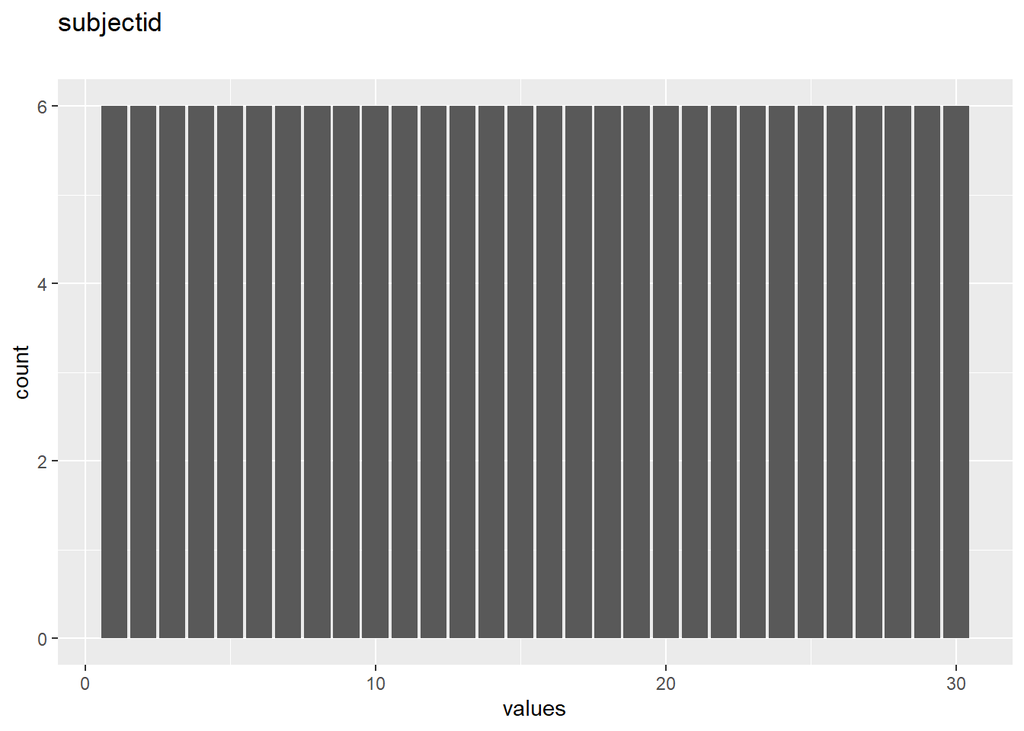

Distribution of values for subjectid

0 missing values.

#### Summary statistics

[output not shown]

### activity_label

#### Distribution

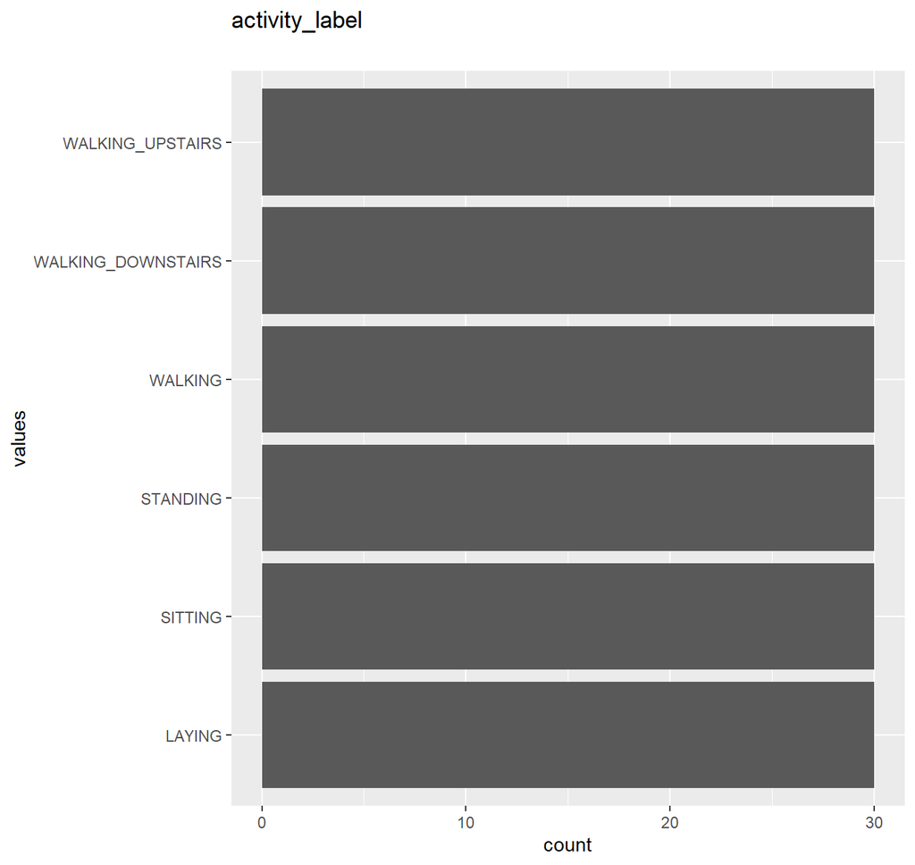

Distribution of values for activity_label

0 missing values.

#### Summary statistics

| name | data_type | n_missing | complete_rate | n_unique | empty | min | max | whitespace | label |
| --- | --- | --- | --- | --- | --- | --- | --- | --- | --- |
| activity_label | character | 0 | 1 | 6 | 0 | 6 | 18 | 0 | NA |

### mean_f1_tBodyAcc.mean.X

#### Distribution

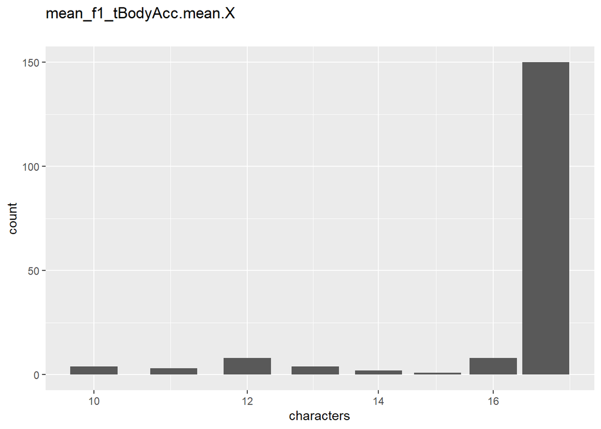

Distribution of values for mean_f1_tBodyAcc.mean.X

0 missing values.

#### Summary statistics

| name | data_type | n_missing | complete_rate | n_unique | empty | min | max | whitespace | label |
| --- | --- | --- | --- | --- | --- | --- | --- | --- | --- |
| mean_f1_tBodyAcc.mean.X | character | 0 | 1 | 180 | 0 | 10 | 17 | 0 | NA |

### mean_f2_tBodyAcc.mean.Y

#### Distribution

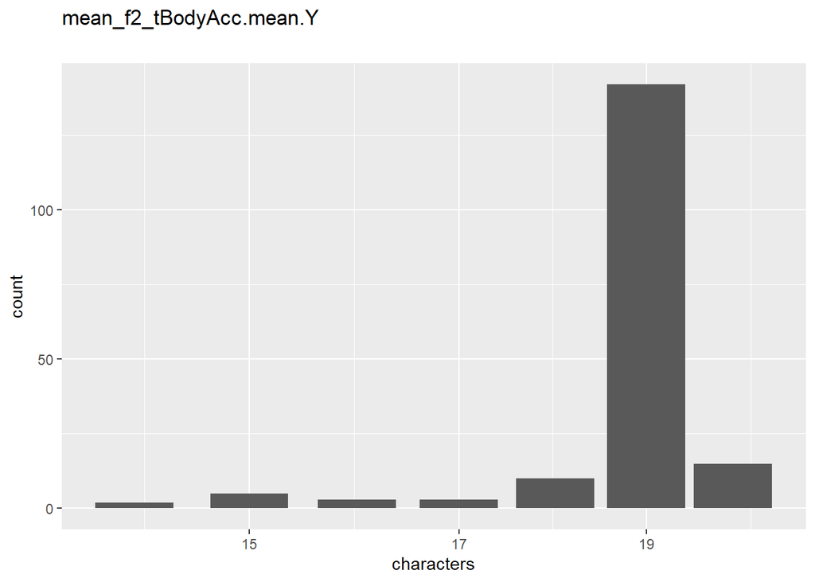

Distribution of values for mean_f2_tBodyAcc.mean.Y

0 missing values.

#### Summary statistics

| name | data_type | n_missing | complete_rate | n_unique | empty | min | max | whitespace | label |
| --- | --- | --- | --- | --- | --- | --- | --- | --- | --- |
| mean_f2_tBodyAcc.mean.Y | character | 0 | 1 | 180 | 0 | 14 | 20 | 0 | NA |

### mean_f3_tBodyAcc.mean.Z

#### Distribution

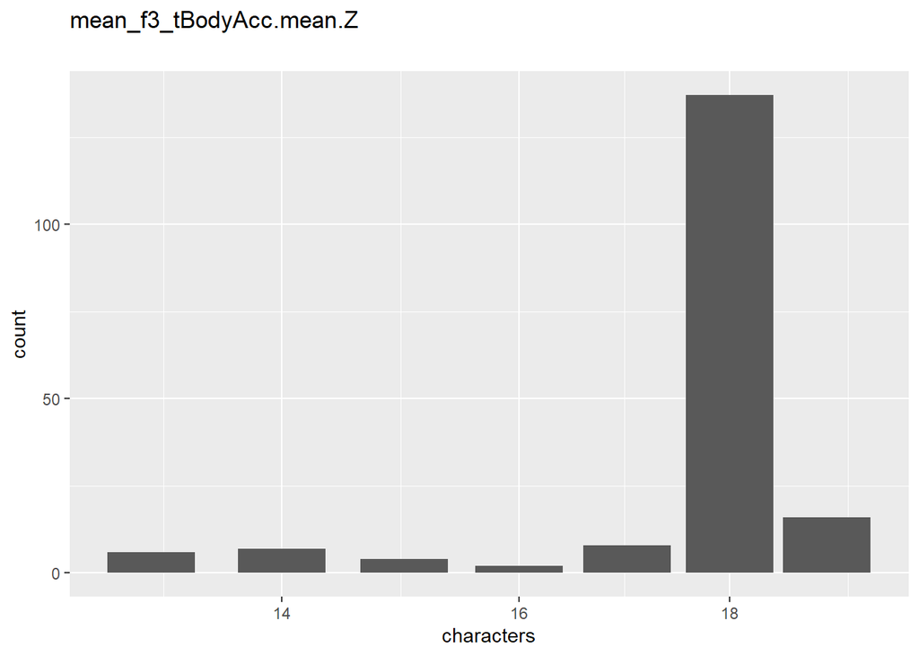

Distribution of values for mean_f3_tBodyAcc.mean.Z

0 missing values.

#### Summary statistics

| name | data_type | n_missing | complete_rate | n_unique | empty | min | max | whitespace | label |
| --- | --- | --- | --- | --- | --- | --- | --- | --- | --- |
| mean_f3_tBodyAcc.mean.Z | character | 0 | 1 | 180 | 0 | 13 | 19 | 0 | NA |

### mean_f4_tBodyAcc.std.X

#### Distribution

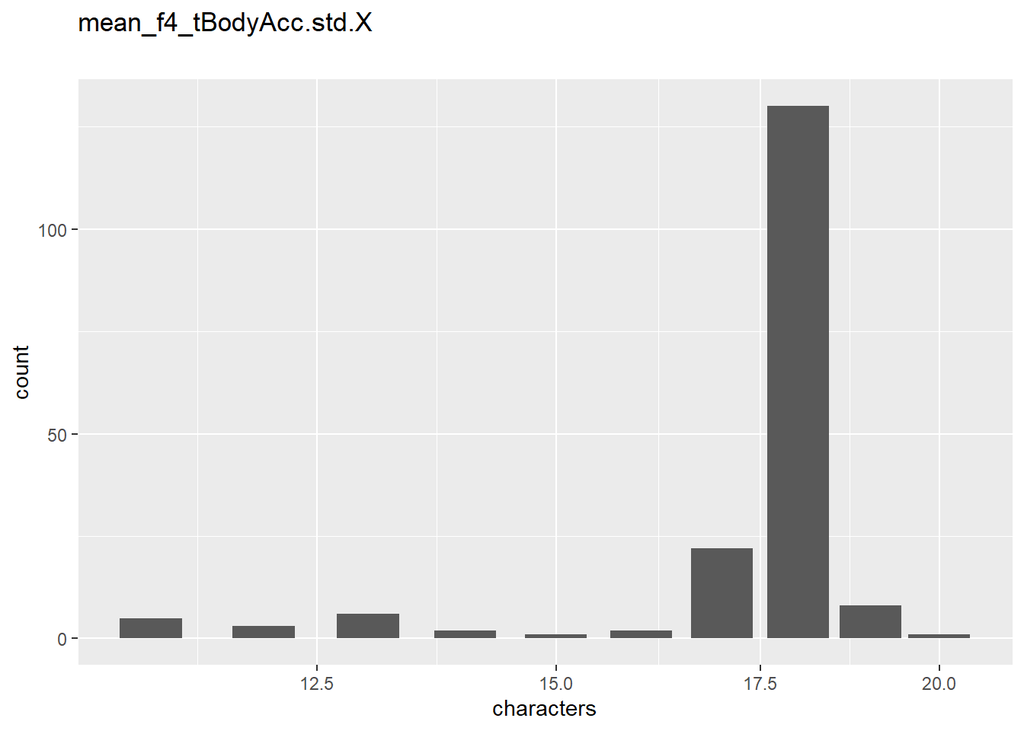

Distribution of values for mean_f4_tBodyAcc.std.X

0 missing values.

#### Summary statistics

| name | data_type | n_missing | complete_rate | n_unique | empty | min | max | whitespace | label |
| --- | --- | --- | --- | --- | --- | --- | --- | --- | --- |
| mean_f4_tBodyAcc.std.X | character | 0 | 1 | 180 | 0 | 11 | 20 | 0 | NA |

### mean_f5_tBodyAcc.std.Y

#### Distribution

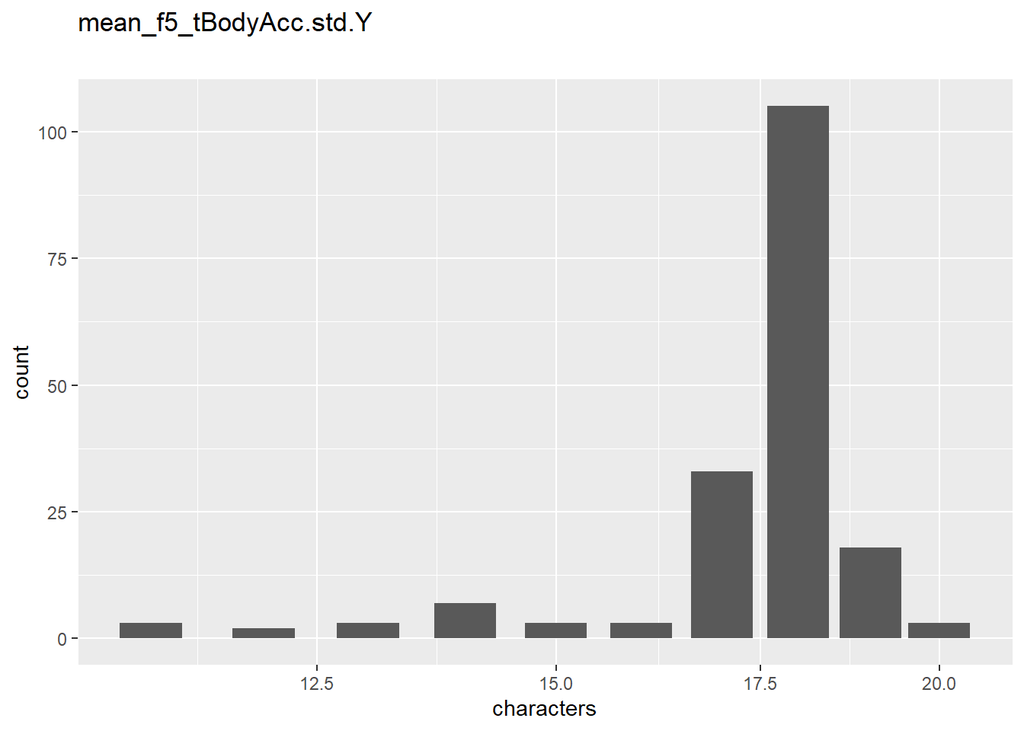

Distribution of values for mean_f5_tBodyAcc.std.Y

0 missing values.

#### Summary statistics

| name | data_type | n_missing | complete_rate | n_unique | empty | min | max | whitespace | label |
| --- | --- | --- | --- | --- | --- | --- | --- | --- | --- |
| mean_f5_tBodyAcc.std.Y | character | 0 | 1 | 180 | 0 | 11 | 20 | 0 | NA |

### mean_f6_tBodyAcc.std.Z

#### Distribution

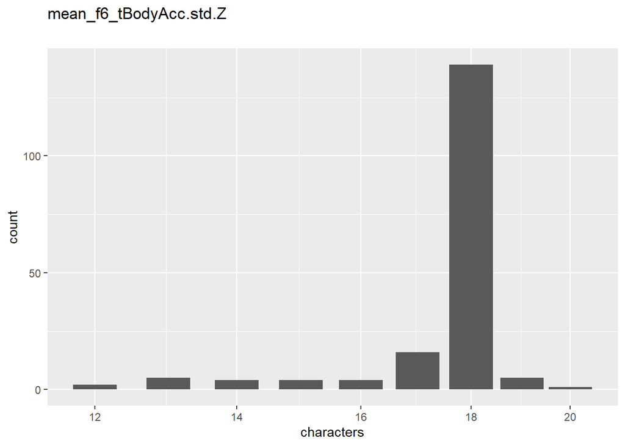

Distribution of values for mean_f6_tBodyAcc.std.Z

0 missing values.

#### Summary statistics

| name | data_type | n_missing | complete_rate | n_unique | empty | min | max | whitespace | label |
| --- | --- | --- | --- | --- | --- | --- | --- | --- | --- |
| mean_f6_tBodyAcc.std.Z | character | 0 | 1 | 180 | 0 | 12 | 20 | 0 | NA |

### mean_f41_tGravityAcc.mean.X

#### Distribution

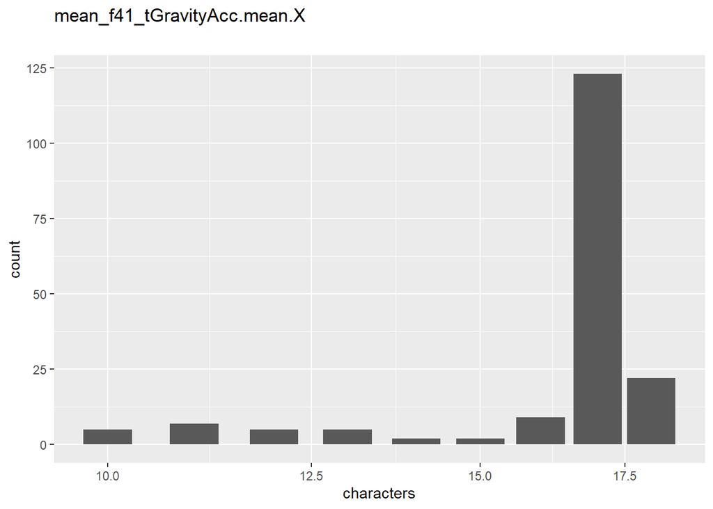

Distribution of values for mean_f41_tGravityAcc.mean.X

0 missing values.

#### Summary statistics

| name | data_type | n_missing | complete_rate | n_unique | empty | min | max | whitespace | label |
| --- | --- | --- | --- | --- | --- | --- | --- | --- | --- |
| mean_f41_tGravityAcc.mean.X | character | 0 | 1 | 180 | 0 | 10 | 18 | 0 | NA |

### mean_f42_tGravityAcc.mean.Y

#### Distribution

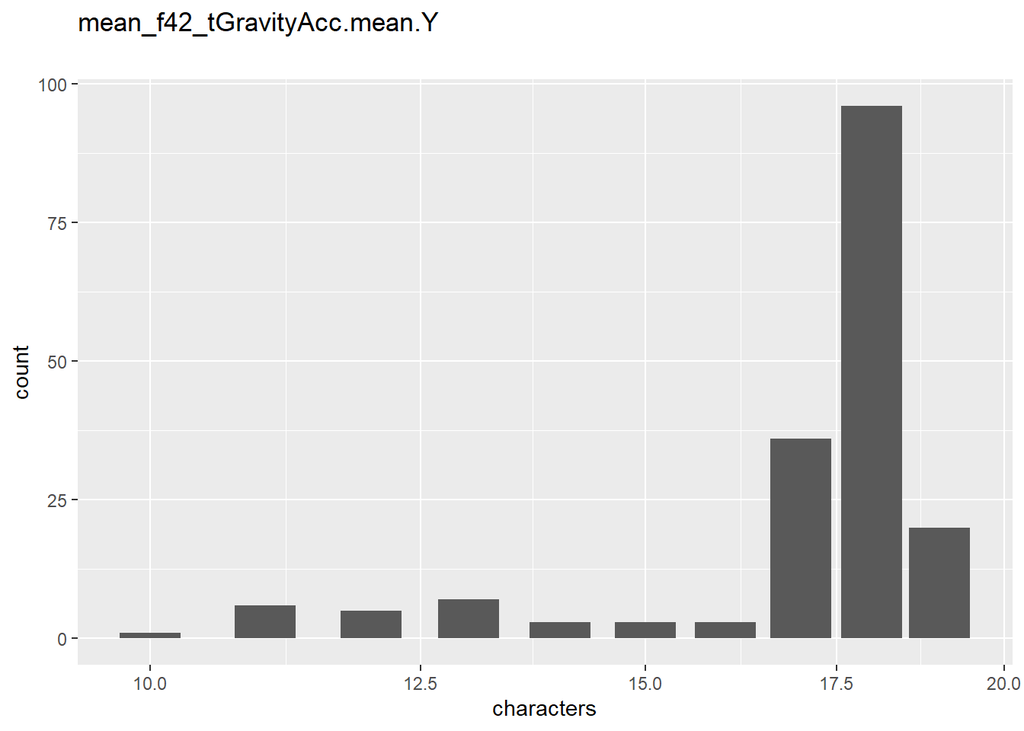

Distribution of values for mean_f42_tGravityAcc.mean.Y

0 missing values.

#### Summary statistics

| name | data_type | n_missing | complete_rate | n_unique | empty | min | max | whitespace | label |
| --- | --- | --- | --- | --- | --- | --- | --- | --- | --- |
| mean_f42_tGravityAcc.mean.Y | character | 0 | 1 | 180 | 0 | 10 | 19 | 0 | NA |

### mean_f43_tGravityAcc.mean.Z

#### Distribution

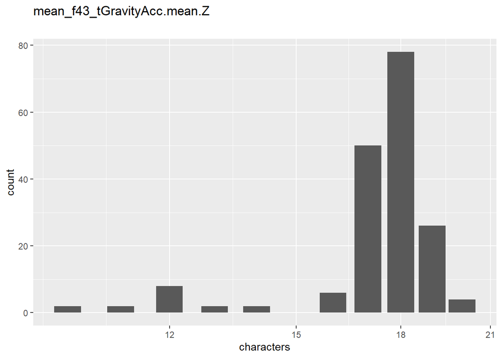

Distribution of values for mean_f43_tGravityAcc.mean.Z

0 missing values.

#### Summary statistics

| name | data_type | n_missing | complete_rate | n_unique | empty | min | max | whitespace | label |
| --- | --- | --- | --- | --- | --- | --- | --- | --- | --- |
| mean_f43_tGravityAcc.mean.Z | character | 0 | 1 | 180 | 0 | 10 | 20 | 0 | NA |

### mean_f44_tGravityAcc.std.X

#### Distribution

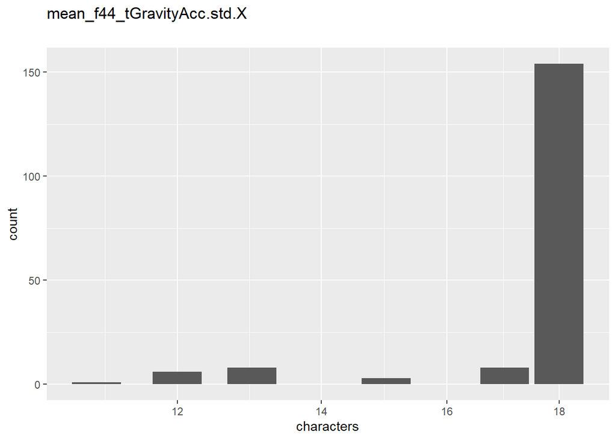

Distribution of values for mean_f44_tGravityAcc.std.X

0 missing values.

#### Summary statistics

| name | data_type | n_missing | complete_rate | n_unique | empty | min | max | whitespace | label |
| --- | --- | --- | --- | --- | --- | --- | --- | --- | --- |
| mean_f44_tGravityAcc.std.X | character | 0 | 1 | 180 | 0 | 11 | 18 | 0 | NA |

### mean_f45_tGravityAcc.std.Y

#### Distribution

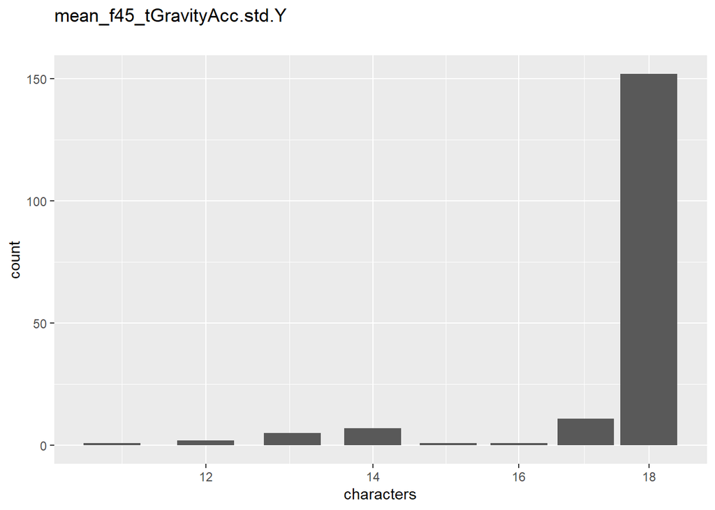

Distribution of values for mean_f45_tGravityAcc.std.Y

0 missing values.

#### Summary statistics

| name | data_type | n_missing | complete_rate | n_unique | empty | min | max | whitespace | label |
| --- | --- | --- | --- | --- | --- | --- | --- | --- | --- |
| mean_f45_tGravityAcc.std.Y | character | 0 | 1 | 180 | 0 | 11 | 18 | 0 | NA |

### mean_f46_tGravityAcc.std.Z

#### Distribution

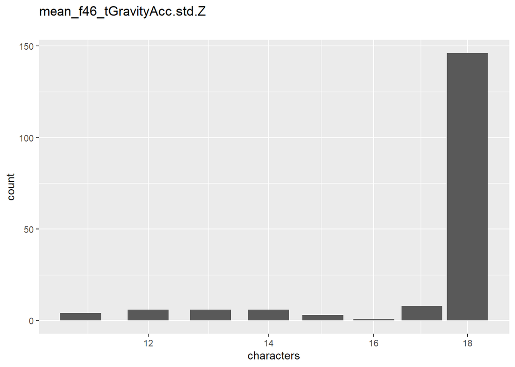

Distribution of values for mean_f46_tGravityAcc.std.Z

0 missing values.

#### Summary statistics

| name | data_type | n_missing | complete_rate | n_unique | empty | min | max | whitespace | label |
| --- | --- | --- | --- | --- | --- | --- | --- | --- | --- |
| mean_f46_tGravityAcc.std.Z | character | 0 | 1 | 180 | 0 | 11 | 18 | 0 | NA |

### mean_f81_tBodyAccJerk.mean.X

#### Distribution

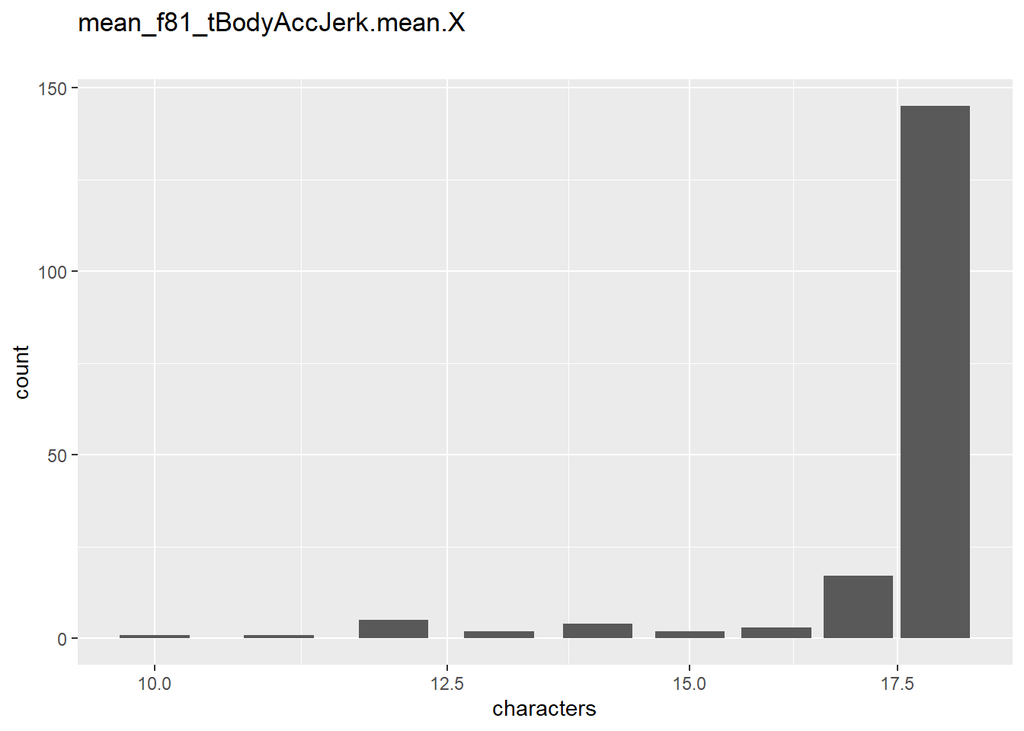

Distribution of values for mean_f81_tBodyAccJerk.mean.X

0 missing values.

#### Summary statistics

| name | data_type | n_missing | complete_rate | n_unique | empty | min | max | whitespace | label |
| --- | --- | --- | --- | --- | --- | --- | --- | --- | --- |
| mean_f81_tBodyAccJerk.mean.X | character | 0 | 1 | 180 | 0 | 10 | 18 | 0 | NA |

### mean_f82_tBodyAccJerk.mean.Y

#### Distribution

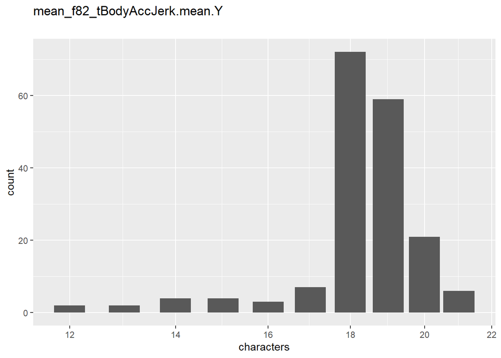

Distribution of values for mean_f82_tBodyAccJerk.mean.Y

0 missing values.

#### Summary statistics

| name | data_type | n_missing | complete_rate | n_unique | empty | min | max | whitespace | label |
| --- | --- | --- | --- | --- | --- | --- | --- | --- | --- |
| mean_f82_tBodyAccJerk.mean.Y | character | 0 | 1 | 180 | 0 | 12 | 21 | 0 | NA |

### mean_f83_tBodyAccJerk.mean.Z

#### Distribution

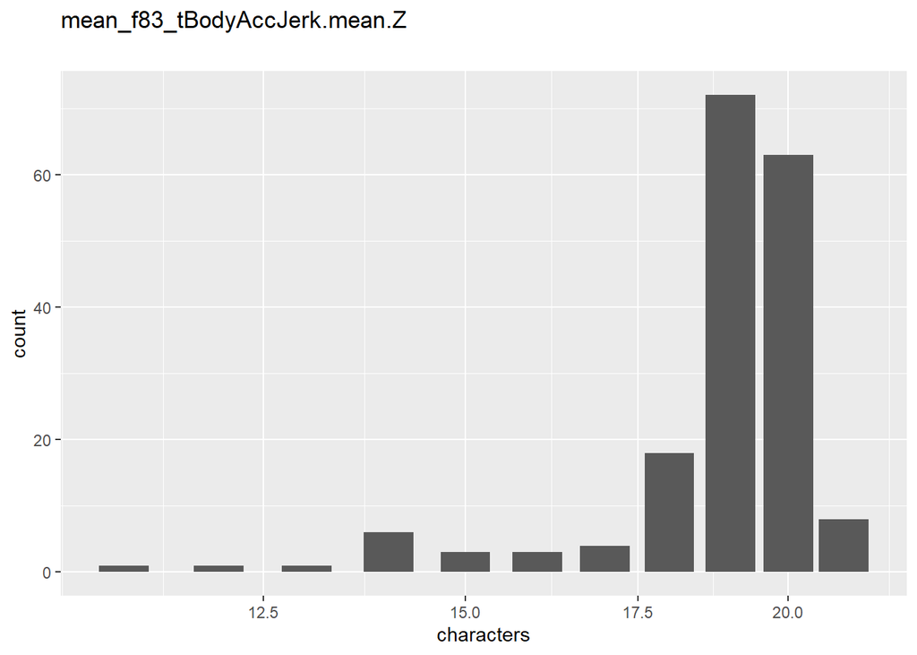

Distribution of values for mean_f83_tBodyAccJerk.mean.Z

0 missing values.

#### Summary statistics

| name | data_type | n_missing | complete_rate | n_unique | empty | min | max | whitespace | label |
| --- | --- | --- | --- | --- | --- | --- | --- | --- | --- |
| mean_f83_tBodyAccJerk.mean.Z | character | 0 | 1 | 180 | 0 | 11 | 21 | 0 | NA |

### mean_f84_tBodyAccJerk.std.X

#### Distribution

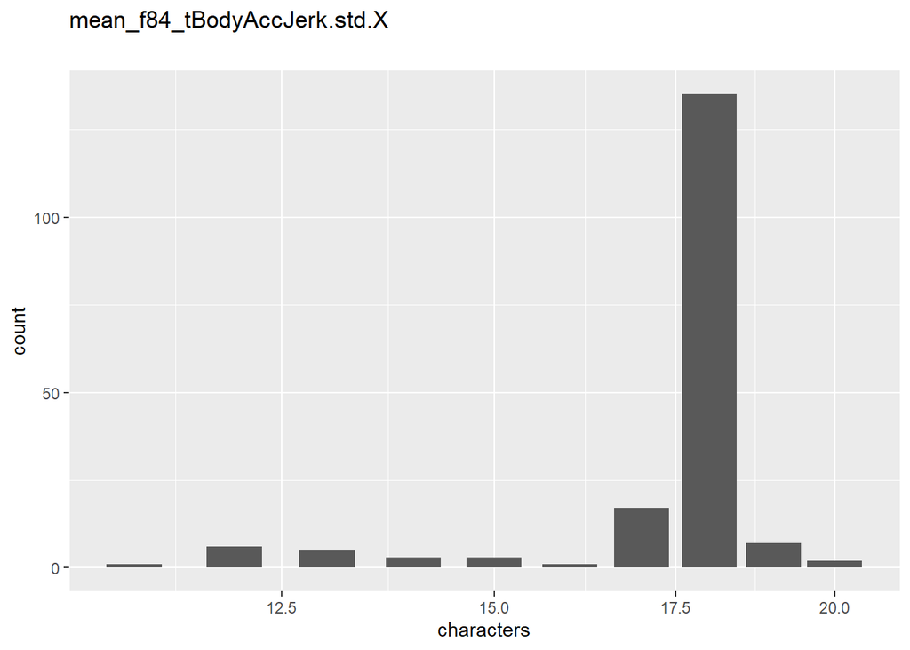

Distribution of values for mean_f84_tBodyAccJerk.std.X

0 missing values.

#### Summary statistics

| name | data_type | n_missing | complete_rate | n_unique | empty | min | max | whitespace | label |
| --- | --- | --- | --- | --- | --- | --- | --- | --- | --- |
| mean_f84_tBodyAccJerk.std.X | character | 0 | 1 | 180 | 0 | 11 | 20 | 0 | NA |

### mean_f85_tBodyAccJerk.std.Y

#### Distribution

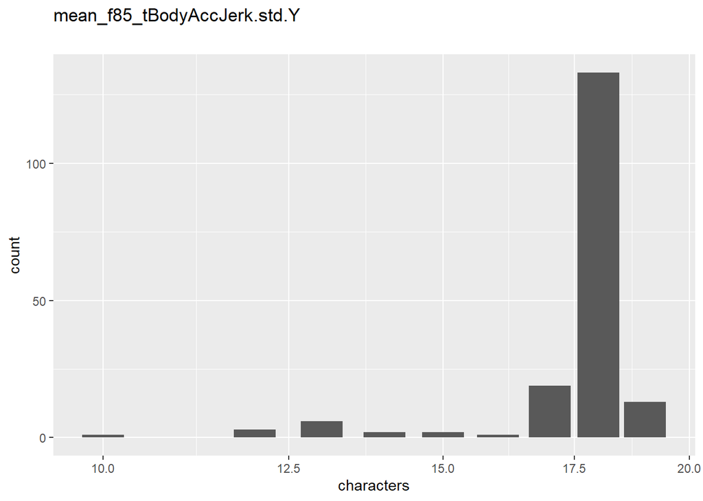

Distribution of values for mean_f85_tBodyAccJerk.std.Y

0 missing values.

#### Summary statistics

| name | data_type | n_missing | complete_rate | n_unique | empty | min | max | whitespace | label |
| --- | --- | --- | --- | --- | --- | --- | --- | --- | --- |
| mean_f85_tBodyAccJerk.std.Y | character | 0 | 1 | 180 | 0 | 10 | 19 | 0 | NA |

### mean_f86_tBodyAccJerk.std.Z

#### Distribution

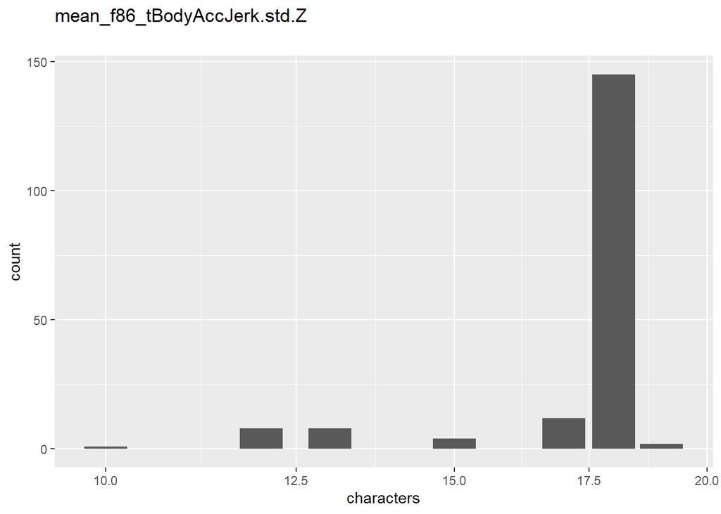

Distribution of values for mean_f86_tBodyAccJerk.std.Z

0 missing values.

#### Summary statistics

| name | data_type | n_missing | complete_rate | n_unique | empty | min | max | whitespace | label |
| --- | --- | --- | --- | --- | --- | --- | --- | --- | --- |
| mean_f86_tBodyAccJerk.std.Z | character | 0 | 1 | 180 | 0 | 10 | 19 | 0 | NA |

### mean_f121_tBodyGyro.mean.X

#### Distribution

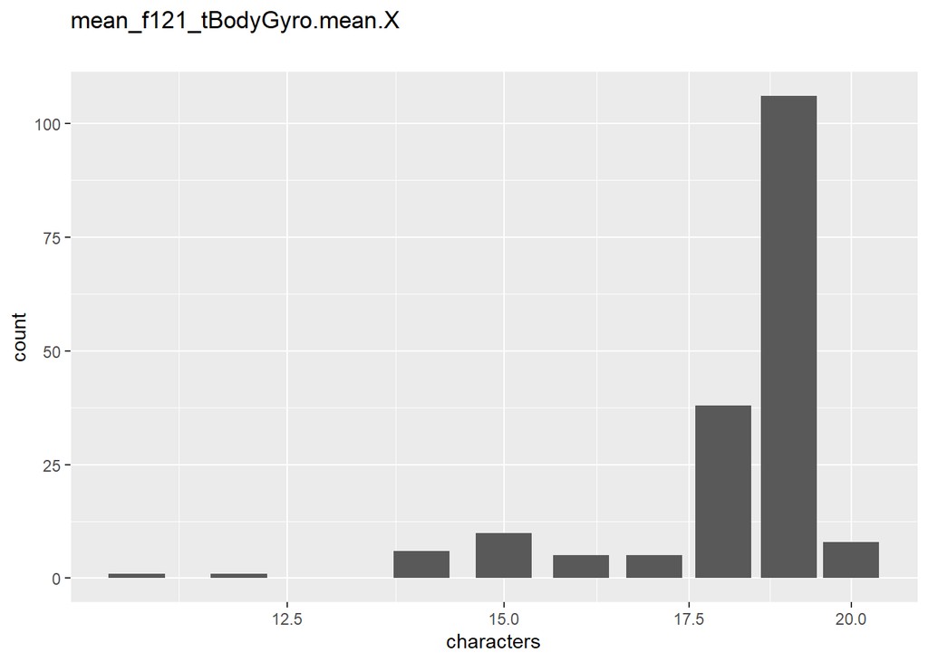

Distribution of values for mean_f121_tBodyGyro.mean.X

0 missing values.

#### Summary statistics

| name | data_type | n_missing | complete_rate | n_unique | empty | min | max | whitespace | label |
| --- | --- | --- | --- | --- | --- | --- | --- | --- | --- |
| mean_f121_tBodyGyro.mean.X | character | 0 | 1 | 180 | 0 | 11 | 20 | 0 | NA |

### mean_f122_tBodyGyro.mean.Y

#### Distribution

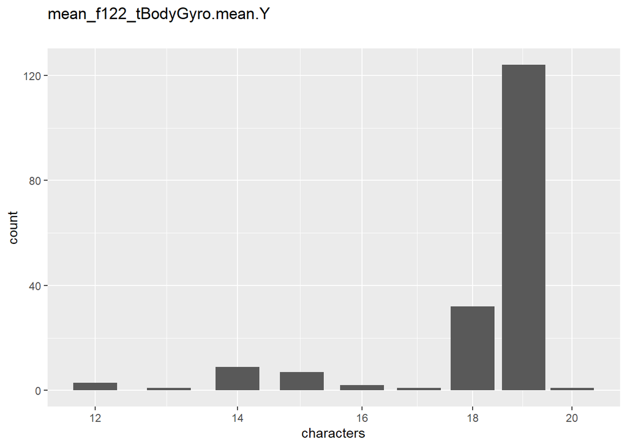

Distribution of values for mean_f122_tBodyGyro.mean.Y

0 missing values.

#### Summary statistics

| name | data_type | n_missing | complete_rate | n_unique | empty | min | max | whitespace | label |
| --- | --- | --- | --- | --- | --- | --- | --- | --- | --- |
| mean_f122_tBodyGyro.mean.Y | character | 0 | 1 | 180 | 0 | 12 | 20 | 0 | NA |

### mean_f123_tBodyGyro.mean.Z

#### Distribution

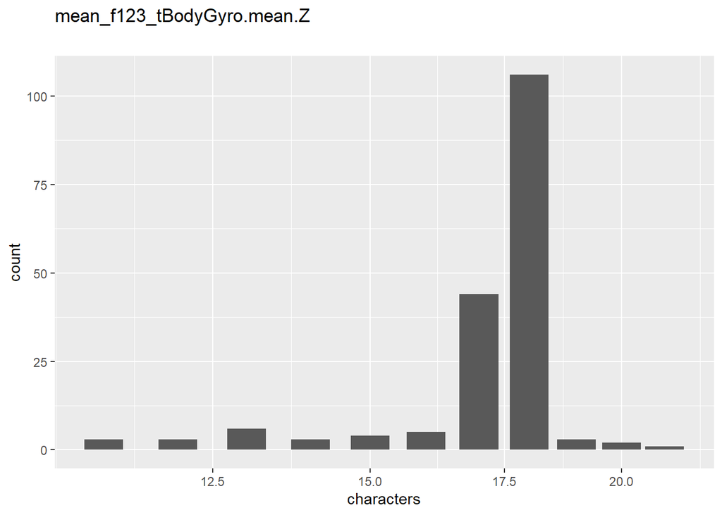

Distribution of values for mean_f123_tBodyGyro.mean.Z

0 missing values.

#### Summary statistics

| name | data_type | n_missing | complete_rate | n_unique | empty | min | max | whitespace | label |
| --- | --- | --- | --- | --- | --- | --- | --- | --- | --- |
| mean_f123_tBodyGyro.mean.Z | character | 0 | 1 | 180 | 0 | 11 | 21 | 0 | NA |

### mean_f124_tBodyGyro.std.X

#### Distribution

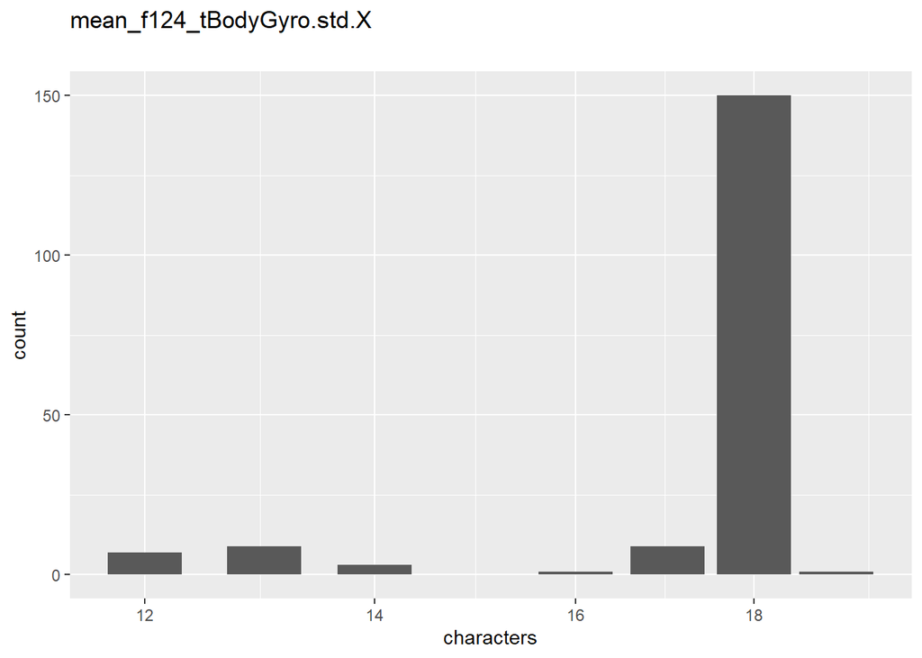

Distribution of values for mean_f124_tBodyGyro.std.X

0 missing values.

#### Summary statistics

| name | data_type | n_missing | complete_rate | n_unique | empty | min | max | whitespace | label |
| --- | --- | --- | --- | --- | --- | --- | --- | --- | --- |
| mean_f124_tBodyGyro.std.X | character | 0 | 1 | 180 | 0 | 12 | 19 | 0 | NA |

### mean_f125_tBodyGyro.std.Y

#### Distribution

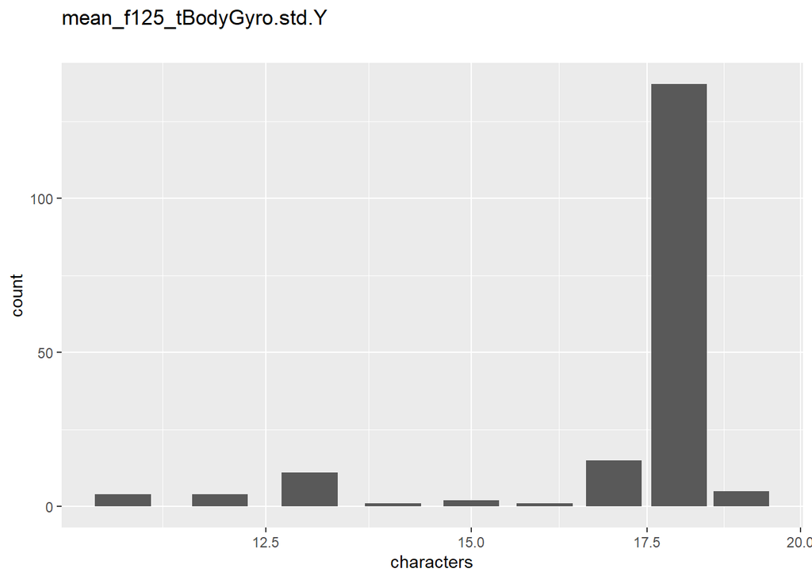

Distribution of values for mean_f125_tBodyGyro.std.Y

0 missing values.

#### Summary statistics

| name | data_type | n_missing | complete_rate | n_unique | empty | min | max | whitespace | label |
| --- | --- | --- | --- | --- | --- | --- | --- | --- | --- |
| mean_f125_tBodyGyro.std.Y | character | 0 | 1 | 180 | 0 | 11 | 19 | 0 | NA |

### mean_f126_tBodyGyro.std.Z

#### Distribution

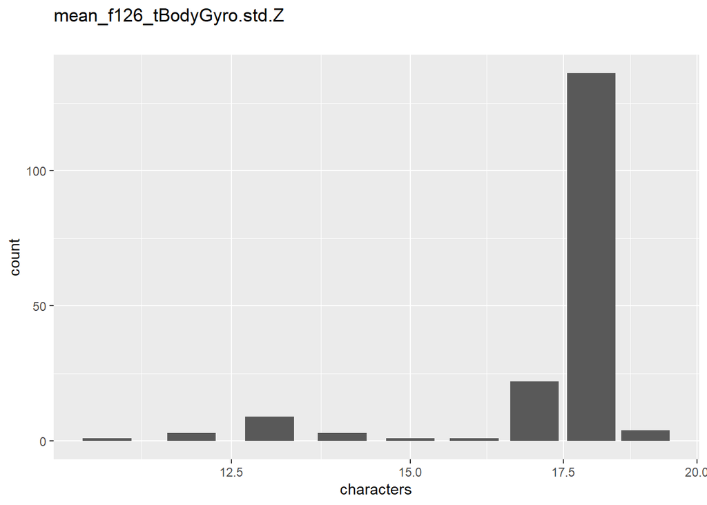

Distribution of values for mean_f126_tBodyGyro.std.Z

0 missing values.

#### Summary statistics

| name | data_type | n_missing | complete_rate | n_unique | empty | min | max | whitespace | label |
| --- | --- | --- | --- | --- | --- | --- | --- | --- | --- |
| mean_f126_tBodyGyro.std.Z | character | 0 | 1 | 180 | 0 | 11 | 19 | 0 | NA |

### mean_f161_tBodyGyroJerk.mean.X

#### Distribution

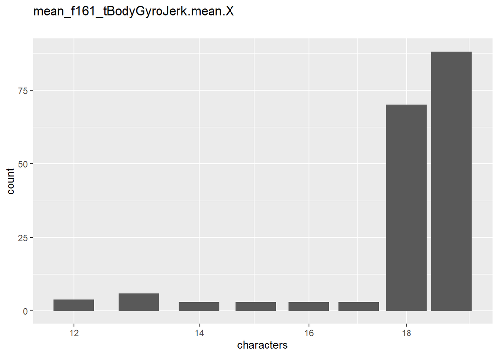

Distribution of values for mean_f161_tBodyGyroJerk.mean.X

0 missing values.

#### Summary statistics

| name | data_type | n_missing | complete_rate | n_unique | empty | min | max | whitespace | label |
| --- | --- | --- | --- | --- | --- | --- | --- | --- | --- |
| mean_f161_tBodyGyroJerk.mean.X | character | 0 | 1 | 180 | 0 | 12 | 19 | 0 | NA |

### mean_f162_tBodyGyroJerk.mean.Y

#### Distribution

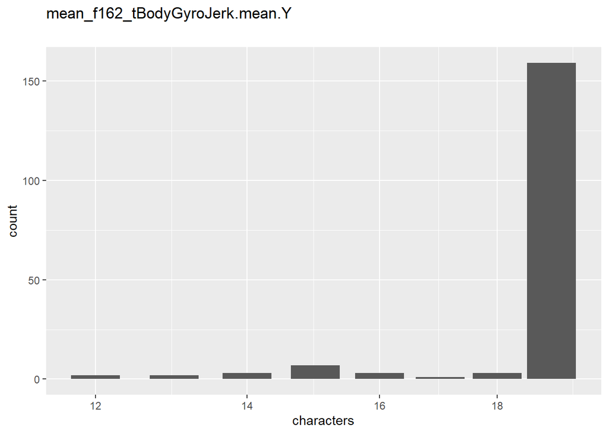

Distribution of values for mean_f162_tBodyGyroJerk.mean.Y

0 missing values.

#### Summary statistics

| name | data_type | n_missing | complete_rate | n_unique | empty | min | max | whitespace | label |
| --- | --- | --- | --- | --- | --- | --- | --- | --- | --- |
| mean_f162_tBodyGyroJerk.mean.Y | character | 0 | 1 | 180 | 0 | 12 | 19 | 0 | NA |

### mean_f163_tBodyGyroJerk.mean.Z

#### Distribution

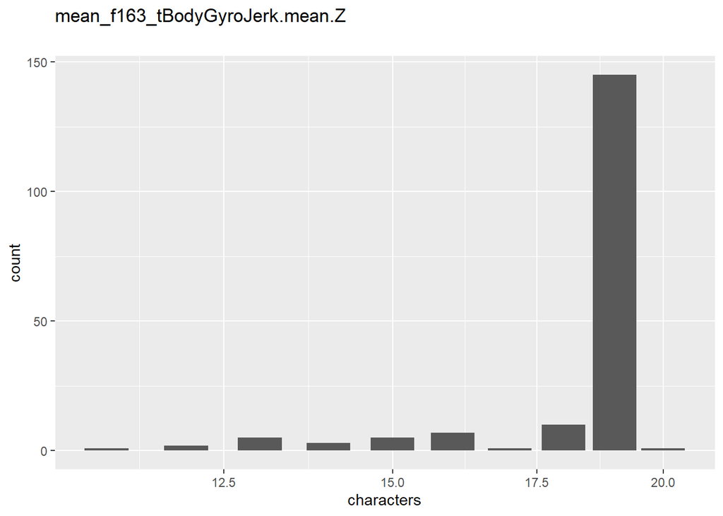

Distribution of values for mean_f163_tBodyGyroJerk.mean.Z

0 missing values.

#### Summary statistics

| name | data_type | n_missing | complete_rate | n_unique | empty | min | max | whitespace | label |
| --- | --- | --- | --- | --- | --- | --- | --- | --- | --- |
| mean_f163_tBodyGyroJerk.mean.Z | character | 0 | 1 | 180 | 0 | 11 | 20 | 0 | NA |

### mean_f164_tBodyGyroJerk.std.X

#### Distribution

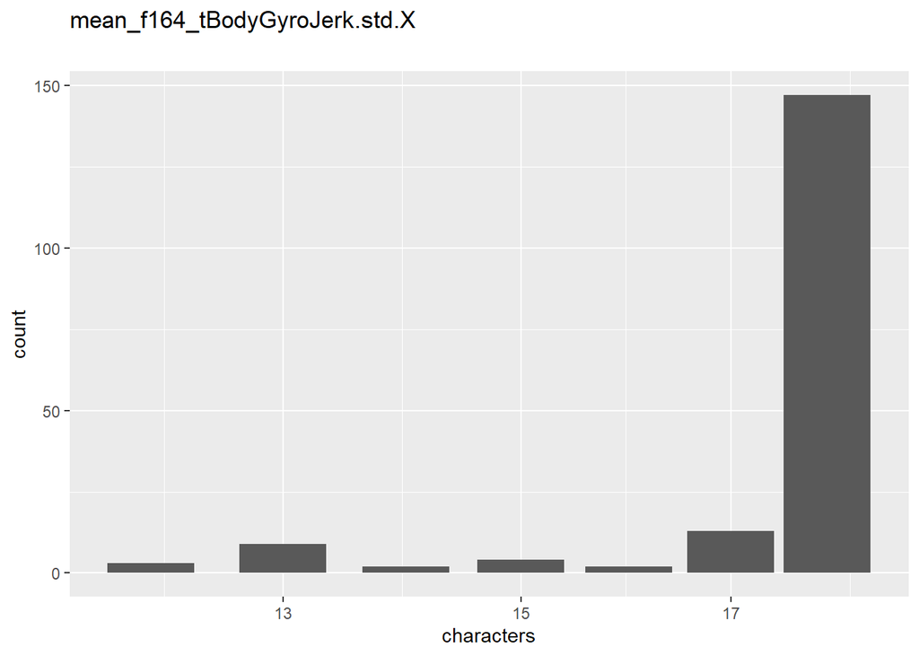

Distribution of values for mean_f164_tBodyGyroJerk.std.X

0 missing values.

#### Summary statistics

| name | data_type | n_missing | complete_rate | n_unique | empty | min | max | whitespace | label |
| --- | --- | --- | --- | --- | --- | --- | --- | --- | --- |
| mean_f164_tBodyGyroJerk.std.X | character | 0 | 1 | 180 | 0 | 12 | 18 | 0 | NA |

### mean_f165_tBodyGyroJerk.std.Y

#### Distribution

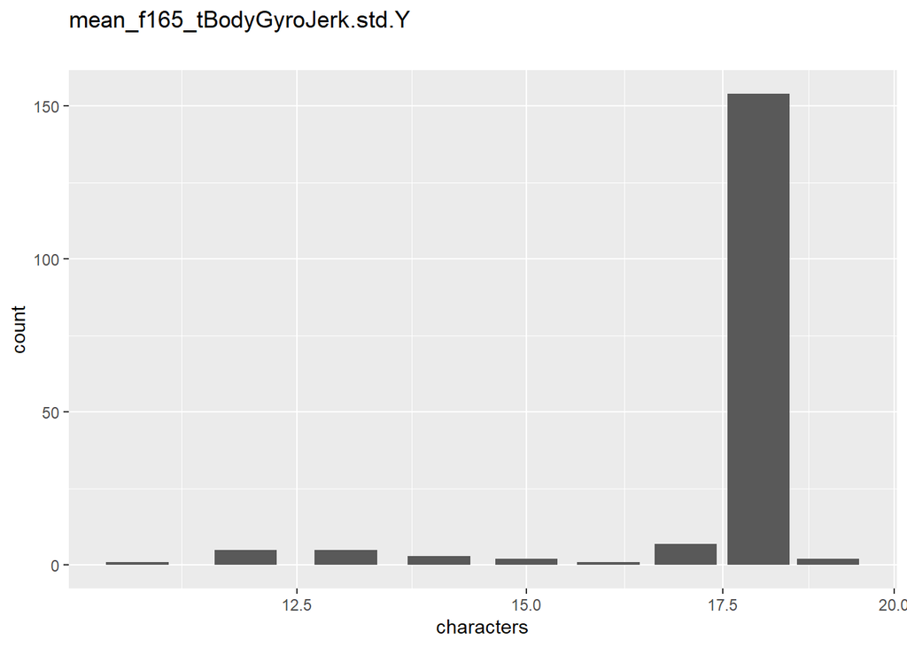

Distribution of values for mean_f165_tBodyGyroJerk.std.Y

0 missing values.

#### Summary statistics

| name | data_type | n_missing | complete_rate | n_unique | empty | min | max | whitespace | label |
| --- | --- | --- | --- | --- | --- | --- | --- | --- | --- |
| mean_f165_tBodyGyroJerk.std.Y | character | 0 | 1 | 180 | 0 | 11 | 19 | 0 | NA |

### mean_f166_tBodyGyroJerk.std.Z

#### Distribution

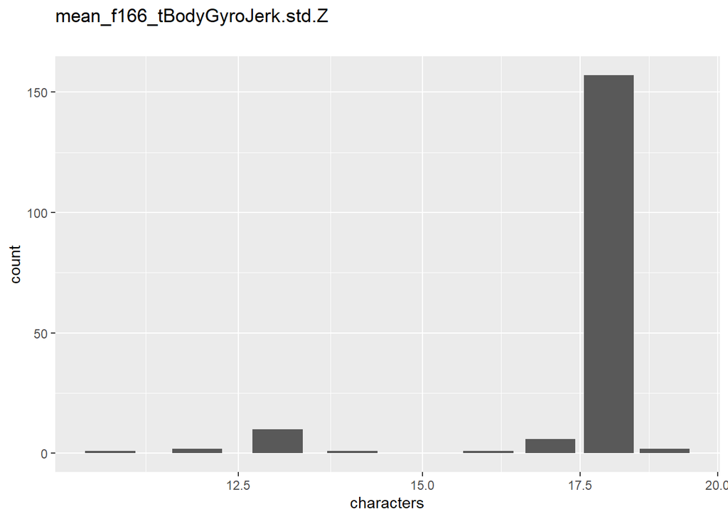

Distribution of values for mean_f166_tBodyGyroJerk.std.Z

0 missing values.

#### Summary statistics

| name | data_type | n_missing | complete_rate | n_unique | empty | min | max | whitespace | label |
| --- | --- | --- | --- | --- | --- | --- | --- | --- | --- |
| mean_f166_tBodyGyroJerk.std.Z | character | 0 | 1 | 180 | 0 | 11 | 19 | 0 | NA |

### mean_f201_tBodyAccMag.mean

#### Distribution

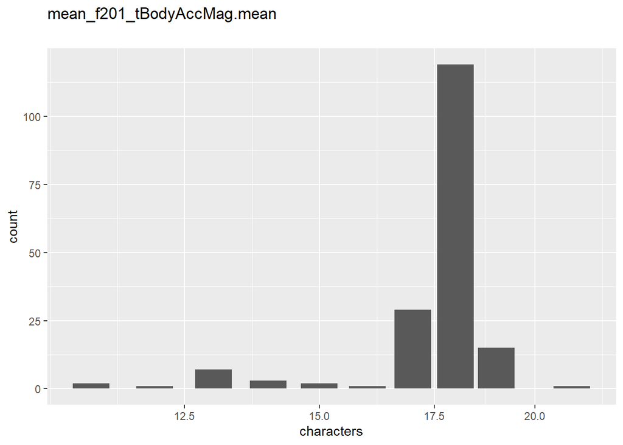

Distribution of values for mean_f201_tBodyAccMag.mean

0 missing values.

#### Summary statistics

| name | data_type | n_missing | complete_rate | n_unique | empty | min | max | whitespace | label |
| --- | --- | --- | --- | --- | --- | --- | --- | --- | --- |
| mean_f201_tBodyAccMag.mean | character | 0 | 1 | 180 | 0 | 11 | 21 | 0 | NA |

### mean_f202_tBodyAccMag.std

#### Distribution

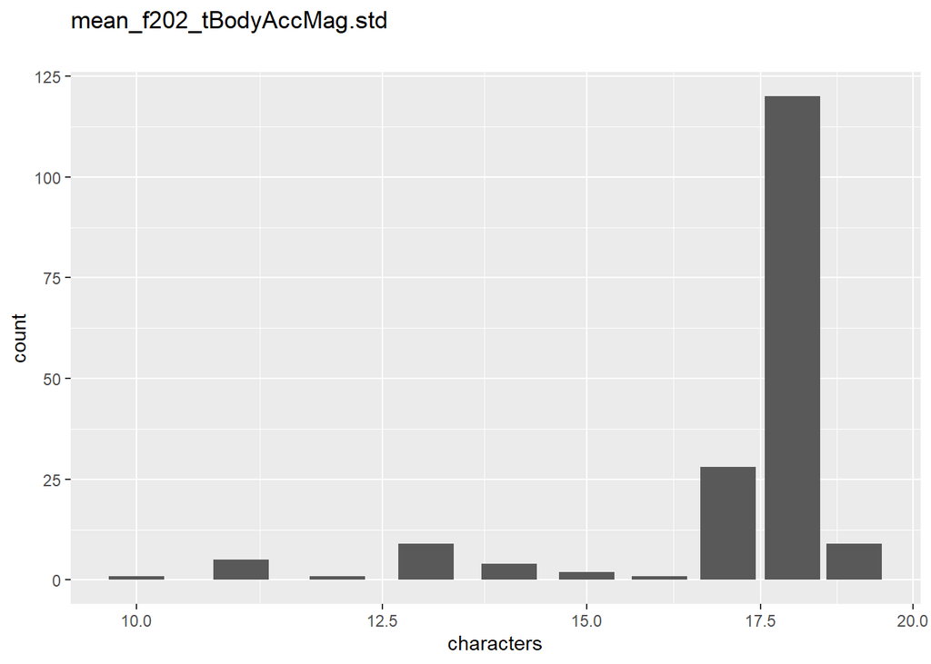

Distribution of values for mean_f202_tBodyAccMag.std

0 missing values.

#### Summary statistics

| name | data_type | n_missing | complete_rate | n_unique | empty | min | max | whitespace | label |
| --- | --- | --- | --- | --- | --- | --- | --- | --- | --- |
| mean_f202_tBodyAccMag.std | character | 0 | 1 | 180 | 0 | 10 | 19 | 0 | NA |

### mean_f214_tGravityAccMag.mean

#### Distribution

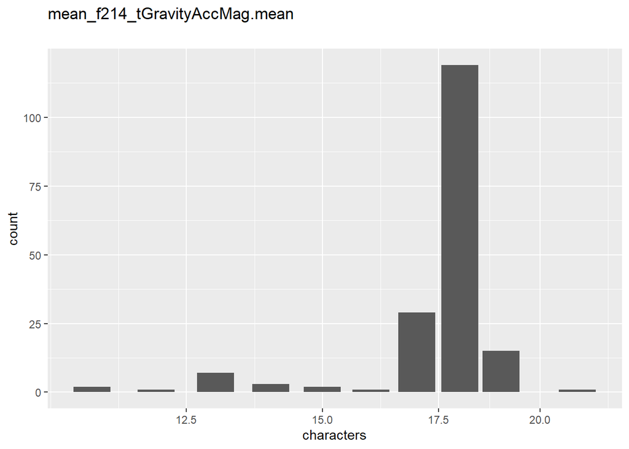

Distribution of values for mean_f214_tGravityAccMag.mean

0 missing values.

#### Summary statistics

| name | data_type | n_missing | complete_rate | n_unique | empty | min | max | whitespace | label |
| --- | --- | --- | --- | --- | --- | --- | --- | --- | --- |
| mean_f214_tGravityAccMag.mean | character | 0 | 1 | 180 | 0 | 11 | 21 | 0 | NA |

### mean_f215_tGravityAccMag.std

#### Distribution

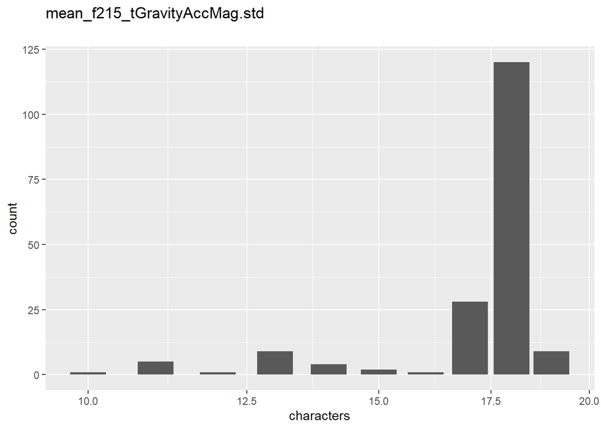

Distribution of values for mean_f215_tGravityAccMag.std

0 missing values.

#### Summary statistics

| name | data_type | n_missing | complete_rate | n_unique | empty | min | max | whitespace | label |
| --- | --- | --- | --- | --- | --- | --- | --- | --- | --- |
| mean_f215_tGravityAccMag.std | character | 0 | 1 | 180 | 0 | 10 | 19 | 0 | NA |

### mean_f227_tBodyAccJerkMag.mean

#### Distribution

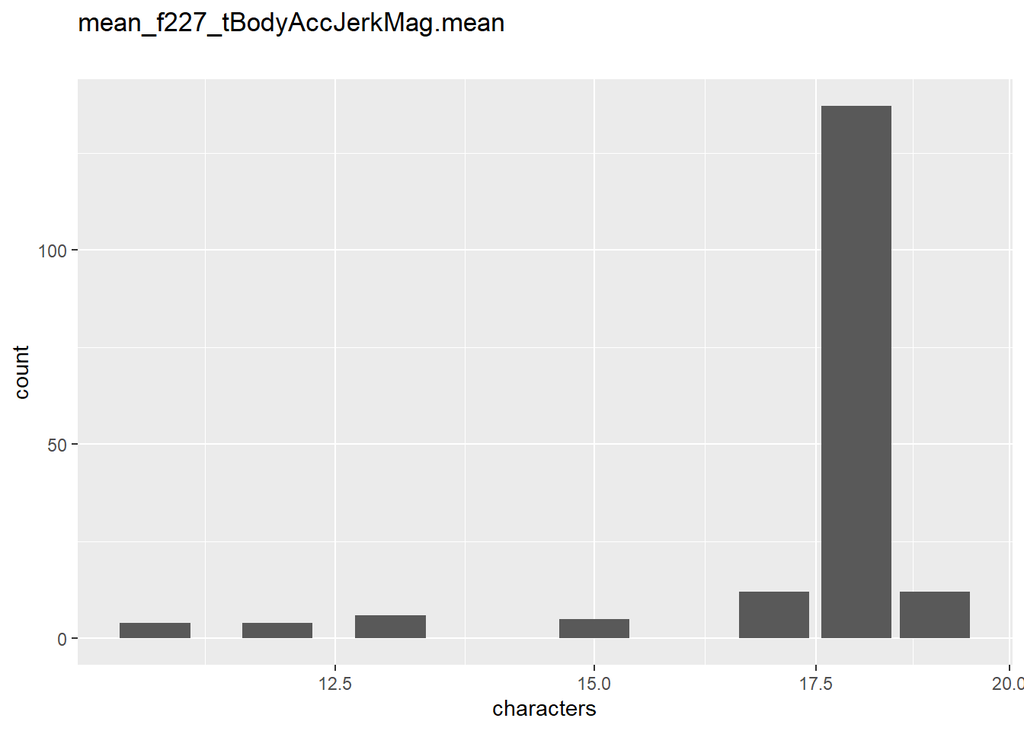

Distribution of values for mean_f227_tBodyAccJerkMag.mean

0 missing values.

#### Summary statistics

| name | data_type | n_missing | complete_rate | n_unique | empty | min | max | whitespace | label |
| --- | --- | --- | --- | --- | --- | --- | --- | --- | --- |
| mean_f227_tBodyAccJerkMag.mean | character | 0 | 1 | 180 | 0 | 11 | 19 | 0 | NA |

### mean_f228_tBodyAccJerkMag.std

#### Distribution

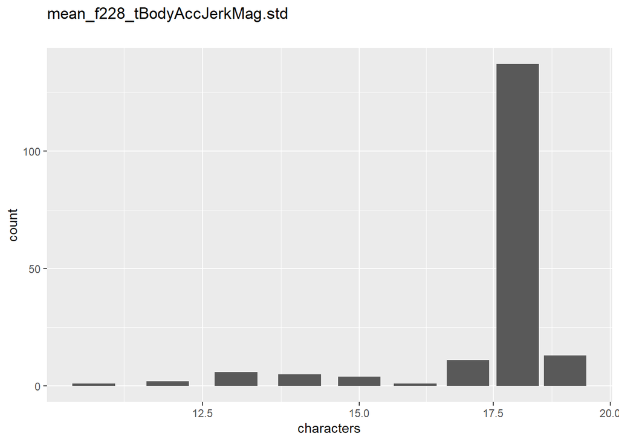

Distribution of values for mean_f228_tBodyAccJerkMag.std

0 missing values.

#### Summary statistics

| name | data_type | n_missing | complete_rate | n_unique | empty | min | max | whitespace | label |
| --- | --- | --- | --- | --- | --- | --- | --- | --- | --- |
| mean_f228_tBodyAccJerkMag.std | character | 0 | 1 | 180 | 0 | 11 | 19 | 0 | NA |

### mean_f240_tBodyGyroMag.mean

#### Distribution

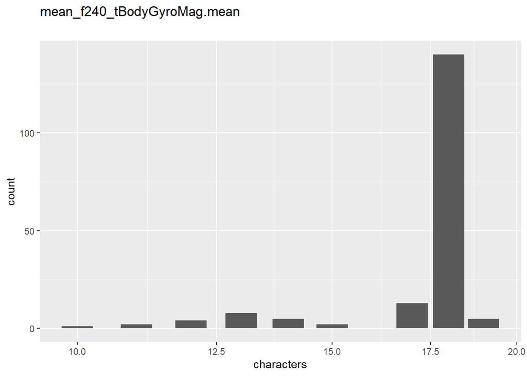

Distribution of values for mean_f240_tBodyGyroMag.mean

0 missing values.

#### Summary statistics

| name | data_type | n_missing | complete_rate | n_unique | empty | min | max | whitespace | label |
| --- | --- | --- | --- | --- | --- | --- | --- | --- | --- |
| mean_f240_tBodyGyroMag.mean | character | 0 | 1 | 180 | 0 | 10 | 19 | 0 | NA |

### mean_f241_tBodyGyroMag.std

#### Distribution

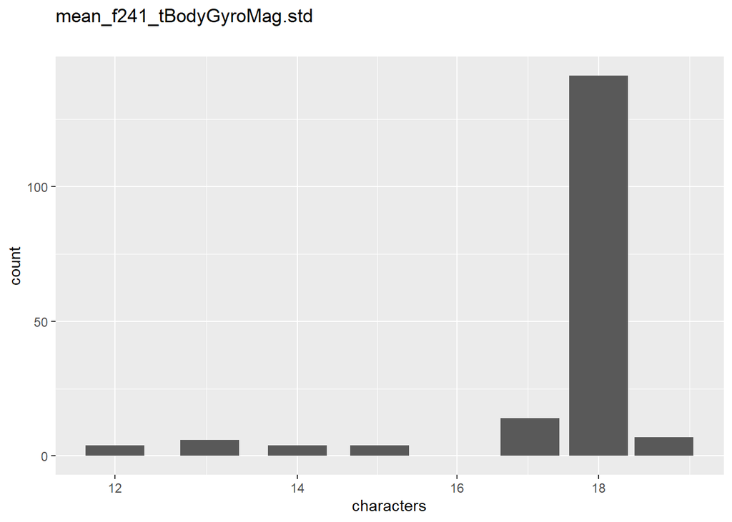

Distribution of values for mean_f241_tBodyGyroMag.std

0 missing values.

#### Summary statistics

| name | data_type | n_missing | complete_rate | n_unique | empty | min | max | whitespace | label |
| --- | --- | --- | --- | --- | --- | --- | --- | --- | --- |
| mean_f241_tBodyGyroMag.std | character | 0 | 1 | 180 | 0 | 12 | 19 | 0 | NA |

### mean_f253_tBodyGyroJerkMag.mean

#### Distribution

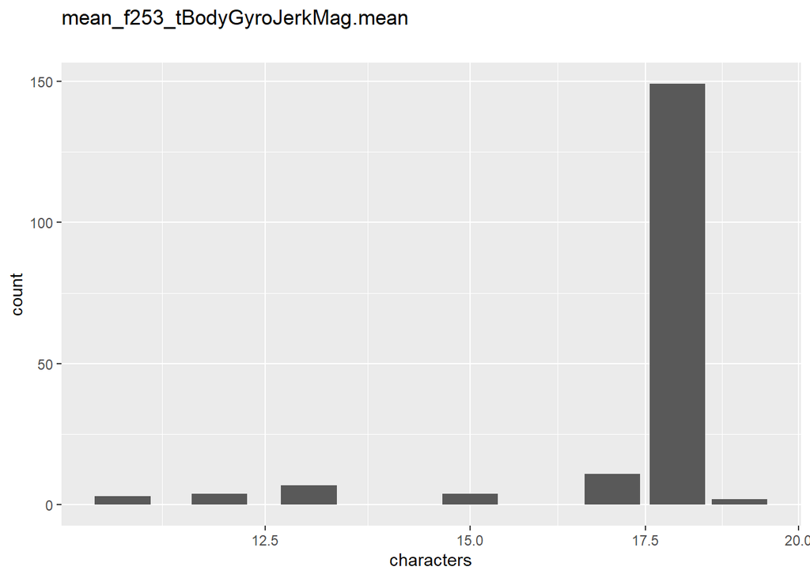

Distribution of values for mean_f253_tBodyGyroJerkMag.mean

0 missing values.

#### Summary statistics

| name | data_type | n_missing | complete_rate | n_unique | empty | min | max | whitespace | label |
| --- | --- | --- | --- | --- | --- | --- | --- | --- | --- |
| mean_f253_tBodyGyroJerkMag.mean | character | 0 | 1 | 180 | 0 | 11 | 19 | 0 | NA |

### mean_f254_tBodyGyroJerkMag.std

#### Distribution

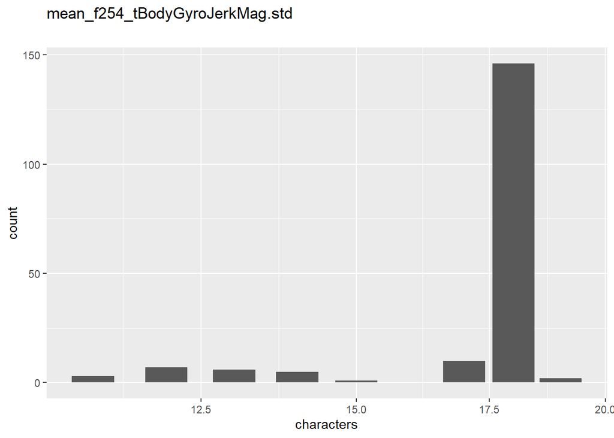

Distribution of values for mean_f254_tBodyGyroJerkMag.std

0 missing values.

#### Summary statistics

| name | data_type | n_missing | complete_rate | n_unique | empty | min | max | whitespace | label |
| --- | --- | --- | --- | --- | --- | --- | --- | --- | --- |
| mean_f254_tBodyGyroJerkMag.std | character | 0 | 1 | 180 | 0 | 11 | 19 | 0 | NA |

### mean_f266_fBodyAcc.mean.X

#### Distribution

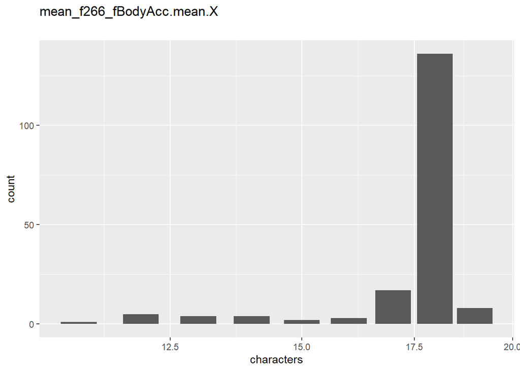

Distribution of values for mean_f266_fBodyAcc.mean.X

0 missing values.

#### Summary statistics

| name | data_type | n_missing | complete_rate | n_unique | empty | min | max | whitespace | label |
| --- | --- | --- | --- | --- | --- | --- | --- | --- | --- |
| mean_f266_fBodyAcc.mean.X | character | 0 | 1 | 180 | 0 | 11 | 19 | 0 | NA |

### mean_f267_fBodyAcc.mean.Y

#### Distribution

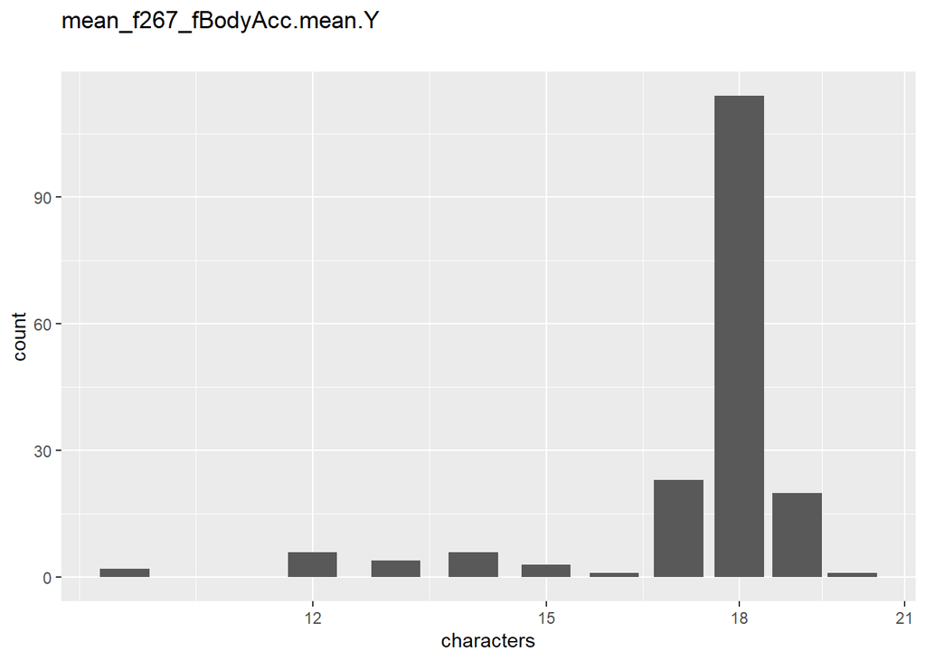

Distribution of values for mean_f267_fBodyAcc.mean.Y

0 missing values.

#### Summary statistics

| name | data_type | n_missing | complete_rate | n_unique | empty | min | max | whitespace | label |
| --- | --- | --- | --- | --- | --- | --- | --- | --- | --- |
| mean_f267_fBodyAcc.mean.Y | character | 0 | 1 | 180 | 0 | 10 | 20 | 0 | NA |

### mean_f268_fBodyAcc.mean.Z

#### Distribution

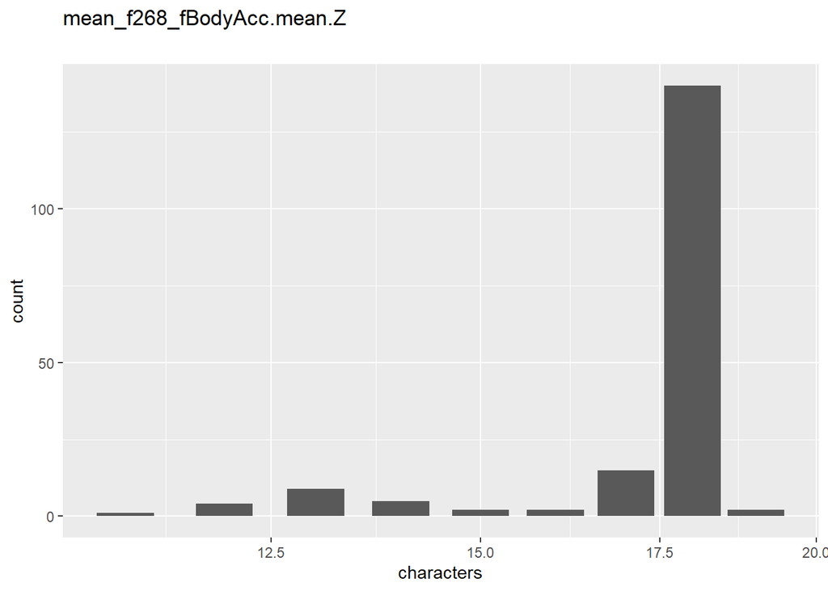

Distribution of values for mean_f268_fBodyAcc.mean.Z

0 missing values.

#### Summary statistics

| name | data_type | n_missing | complete_rate | n_unique | empty | min | max | whitespace | label |
| --- | --- | --- | --- | --- | --- | --- | --- | --- | --- |
| mean_f268_fBodyAcc.mean.Z | character | 0 | 1 | 180 | 0 | 11 | 19 | 0 | NA |

### mean_f269_fBodyAcc.std.X

#### Distribution

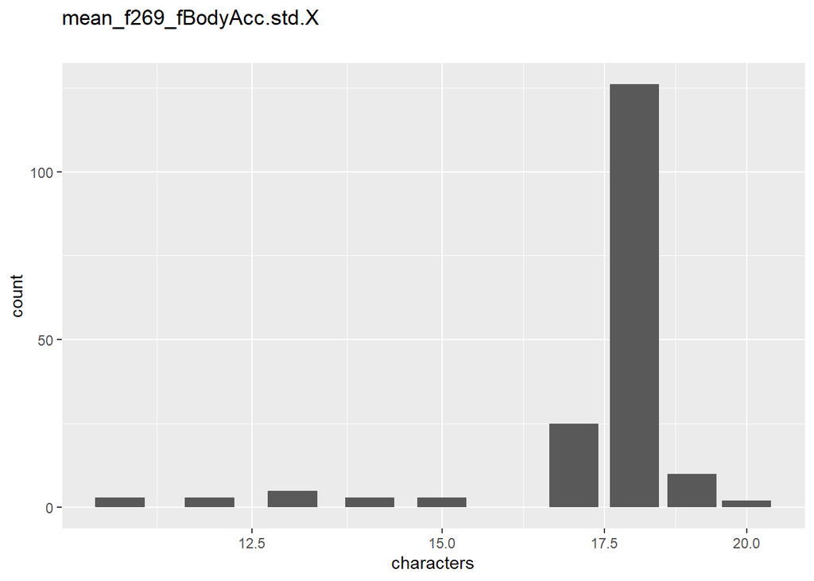

Distribution of values for mean_f269_fBodyAcc.std.X

0 missing values.

#### Summary statistics

| name | data_type | n_missing | complete_rate | n_unique | empty | min | max | whitespace | label |
| --- | --- | --- | --- | --- | --- | --- | --- | --- | --- |
| mean_f269_fBodyAcc.std.X | character | 0 | 1 | 180 | 0 | 11 | 20 | 0 | NA |

### mean_f270_fBodyAcc.std.Y

#### Distribution

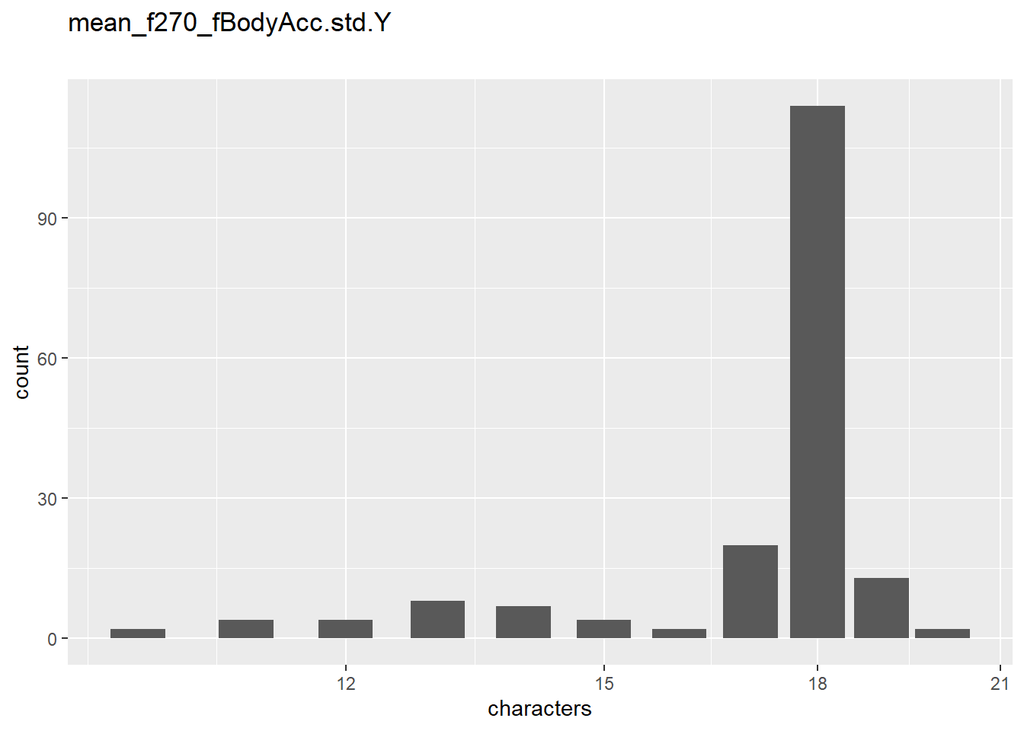

Distribution of values for mean_f270_fBodyAcc.std.Y

0 missing values.

#### Summary statistics

| name | data_type | n_missing | complete_rate | n_unique | empty | min | max | whitespace | label |
| --- | --- | --- | --- | --- | --- | --- | --- | --- | --- |
| mean_f270_fBodyAcc.std.Y | character | 0 | 1 | 180 | 0 | 10 | 20 | 0 | NA |

### mean_f271_fBodyAcc.std.Z

#### Distribution

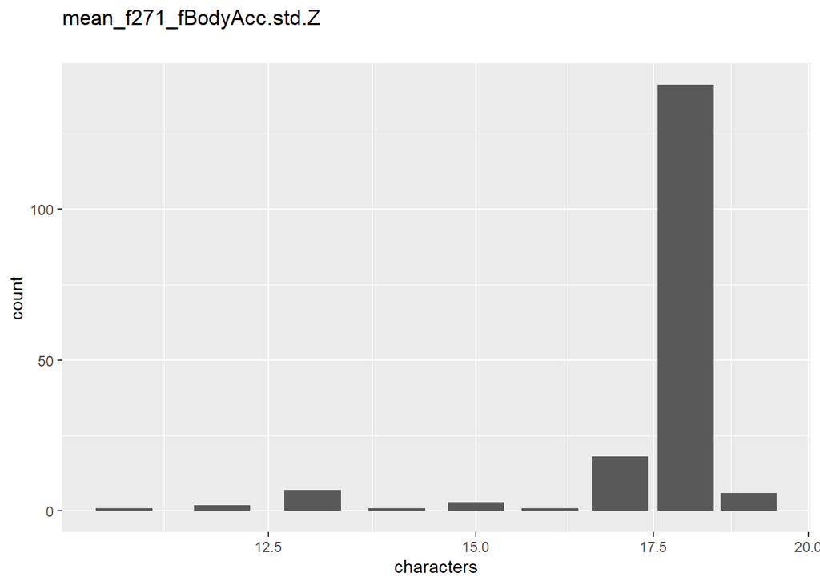

Distribution of values for mean_f271_fBodyAcc.std.Z

0 missing values.

#### Summary statistics

| name | data_type | n_missing | complete_rate | n_unique | empty | min | max | whitespace | label |
| --- | --- | --- | --- | --- | --- | --- | --- | --- | --- |
| mean_f271_fBodyAcc.std.Z | character | 0 | 1 | 180 | 0 | 11 | 19 | 0 | NA |

### mean_f345_fBodyAccJerk.mean.X

#### Distribution

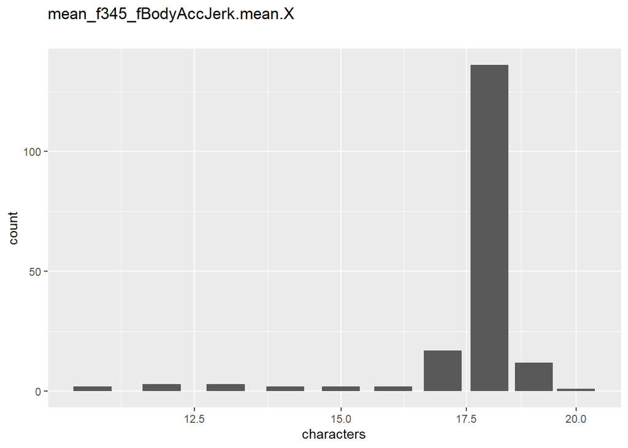

Distribution of values for mean_f345_fBodyAccJerk.mean.X

0 missing values.

#### Summary statistics

| name | data_type | n_missing | complete_rate | n_unique | empty | min | max | whitespace | label |
| --- | --- | --- | --- | --- | --- | --- | --- | --- | --- |
| mean_f345_fBodyAccJerk.mean.X | character | 0 | 1 | 180 | 0 | 11 | 20 | 0 | NA |

### mean_f346_fBodyAccJerk.mean.Y

#### Distribution

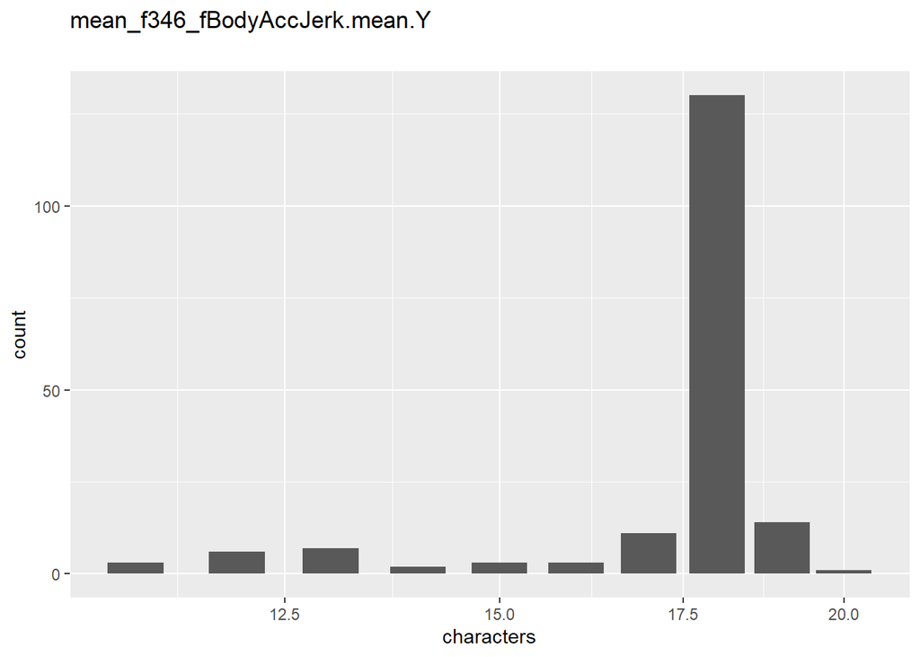

Distribution of values for mean_f346_fBodyAccJerk.mean.Y

0 missing values.

#### Summary statistics

| name | data_type | n_missing | complete_rate | n_unique | empty | min | max | whitespace | label |
| --- | --- | --- | --- | --- | --- | --- | --- | --- | --- |
| mean_f346_fBodyAccJerk.mean.Y | character | 0 | 1 | 180 | 0 | 11 | 20 | 0 | NA |

### mean_f347_fBodyAccJerk.mean.Z

#### Distribution

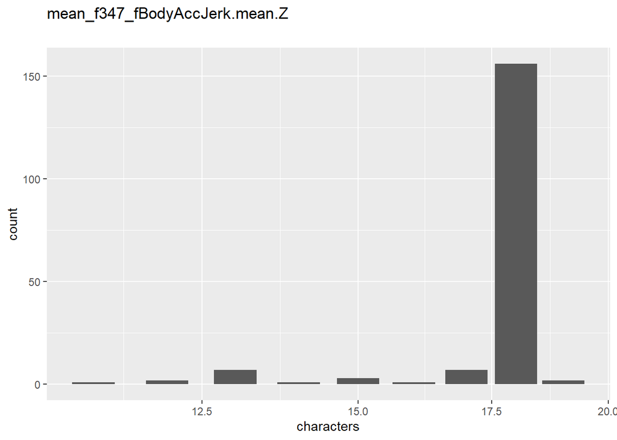

Distribution of values for mean_f347_fBodyAccJerk.mean.Z

0 missing values.

#### Summary statistics

| name | data_type | n_missing | complete_rate | n_unique | empty | min | max | whitespace | label |
| --- | --- | --- | --- | --- | --- | --- | --- | --- | --- |
| mean_f347_fBodyAccJerk.mean.Z | character | 0 | 1 | 180 | 0 | 11 | 19 | 0 | NA |

### mean_f348_fBodyAccJerk.std.X

#### Distribution

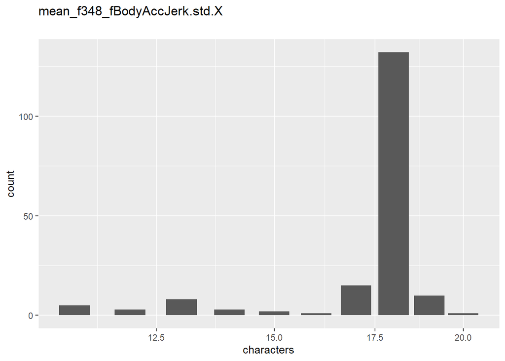

Distribution of values for mean_f348_fBodyAccJerk.std.X

0 missing values.

#### Summary statistics

| name | data_type | n_missing | complete_rate | n_unique | empty | min | max | whitespace | label |
| --- | --- | --- | --- | --- | --- | --- | --- | --- | --- |
| mean_f348_fBodyAccJerk.std.X | character | 0 | 1 | 180 | 0 | 11 | 20 | 0 | NA |

### mean_f349_fBodyAccJerk.std.Y

#### Distribution

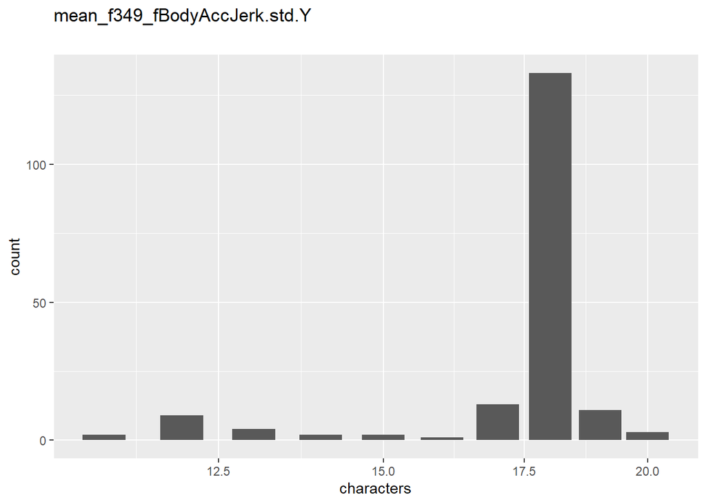

Distribution of values for mean_f349_fBodyAccJerk.std.Y

0 missing values.

#### Summary statistics

| name | data_type | n_missing | complete_rate | n_unique | empty | min | max | whitespace | label |
| --- | --- | --- | --- | --- | --- | --- | --- | --- | --- |
| mean_f349_fBodyAccJerk.std.Y | character | 0 | 1 | 180 | 0 | 11 | 20 | 0 | NA |

### mean_f350_fBodyAccJerk.std.Z

#### Distribution

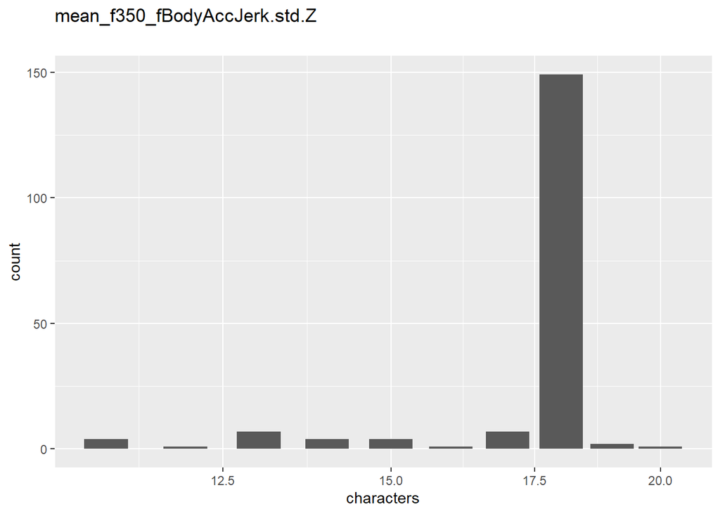

Distribution of values for mean_f350_fBodyAccJerk.std.Z

0 missing values.

#### Summary statistics

| name | data_type | n_missing | complete_rate | n_unique | empty | min | max | whitespace | label |
| --- | --- | --- | --- | --- | --- | --- | --- | --- | --- |
| mean_f350_fBodyAccJerk.std.Z | character | 0 | 1 | 180 | 0 | 11 | 20 | 0 | NA |

### mean_f424_fBodyGyro.mean.X

#### Distribution

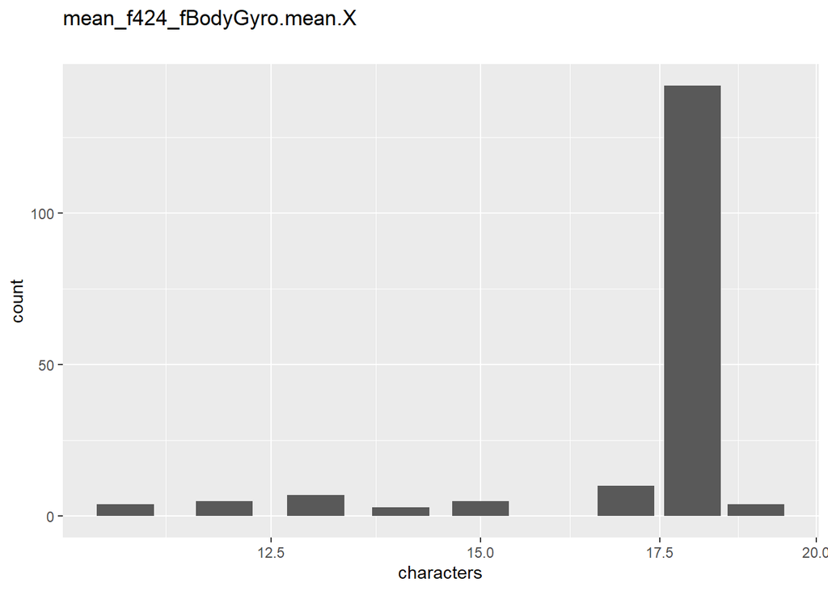

Distribution of values for mean_f424_fBodyGyro.mean.X

0 missing values.

#### Summary statistics

| name | data_type | n_missing | complete_rate | n_unique | empty | min | max | whitespace | label |
| --- | --- | --- | --- | --- | --- | --- | --- | --- | --- |
| mean_f424_fBodyGyro.mean.X | character | 0 | 1 | 180 | 0 | 11 | 19 | 0 | NA |

### mean_f425_fBodyGyro.mean.Y

#### Distribution

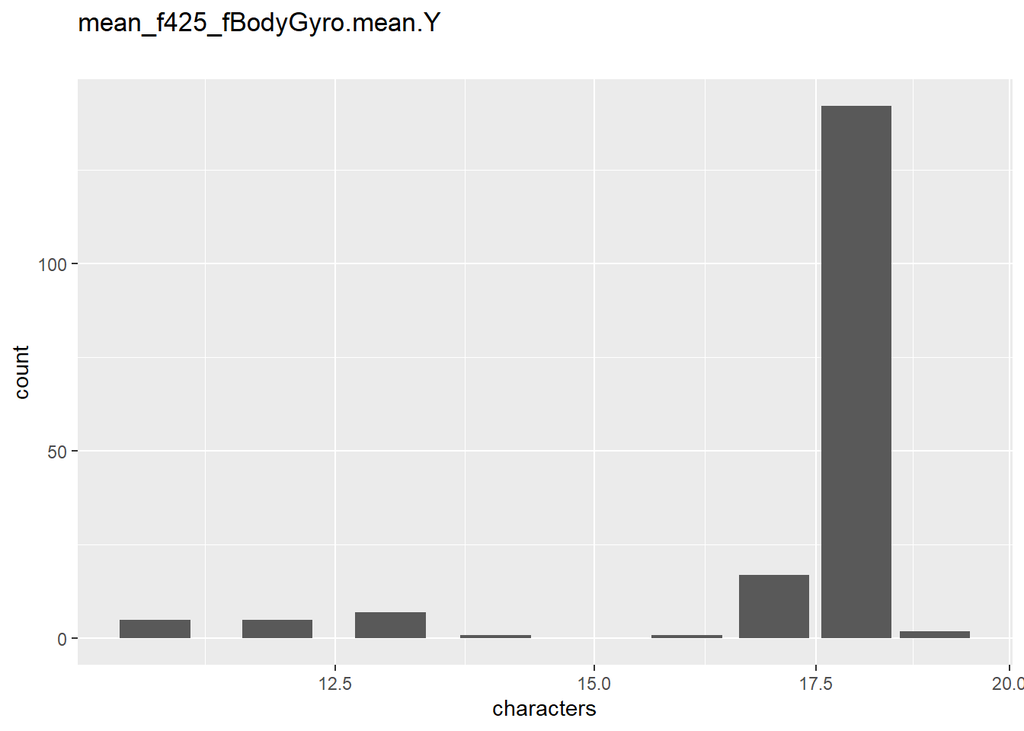

Distribution of values for mean_f425_fBodyGyro.mean.Y

0 missing values.

#### Summary statistics

| name | data_type | n_missing | complete_rate | n_unique | empty | min | max | whitespace | label |
| --- | --- | --- | --- | --- | --- | --- | --- | --- | --- |
| mean_f425_fBodyGyro.mean.Y | character | 0 | 1 | 180 | 0 | 11 | 19 | 0 | NA |

### mean_f426_fBodyGyro.mean.Z

#### Distribution

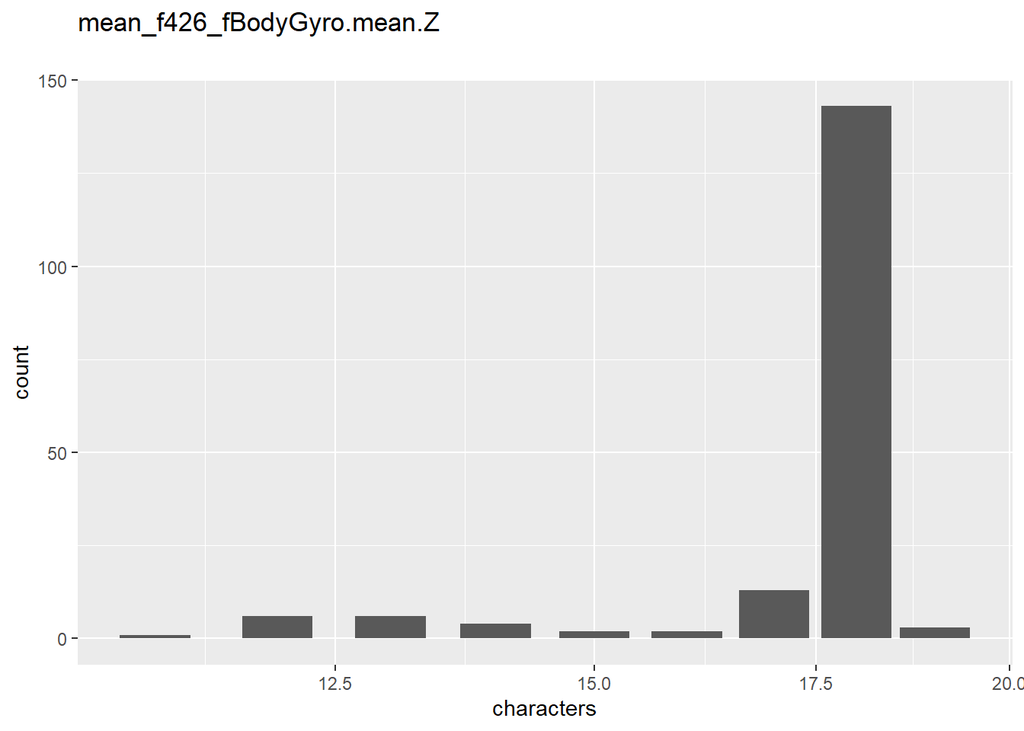

Distribution of values for mean_f426_fBodyGyro.mean.Z

0 missing values.

#### Summary statistics

| name | data_type | n_missing | complete_rate | n_unique | empty | min | max | whitespace | label |
| --- | --- | --- | --- | --- | --- | --- | --- | --- | --- |
| mean_f426_fBodyGyro.mean.Z | character | 0 | 1 | 180 | 0 | 11 | 19 | 0 | NA |

### mean_f427_fBodyGyro.std.X

#### Distribution

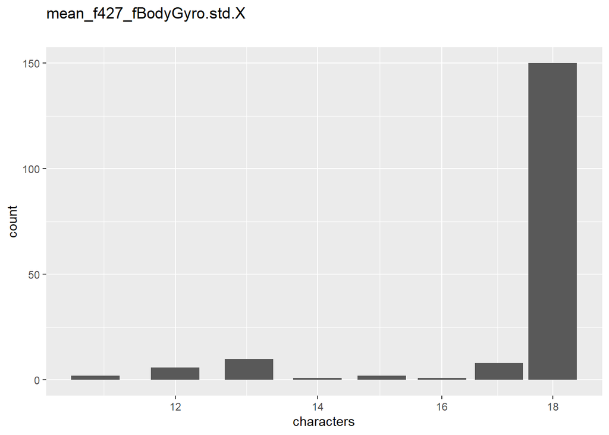

Distribution of values for mean_f427_fBodyGyro.std.X

0 missing values.

#### Summary statistics

| name | data_type | n_missing | complete_rate | n_unique | empty | min | max | whitespace | label |
| --- | --- | --- | --- | --- | --- | --- | --- | --- | --- |
| mean_f427_fBodyGyro.std.X | character | 0 | 1 | 180 | 0 | 11 | 18 | 0 | NA |

### mean_f428_fBodyGyro.std.Y

#### Distribution

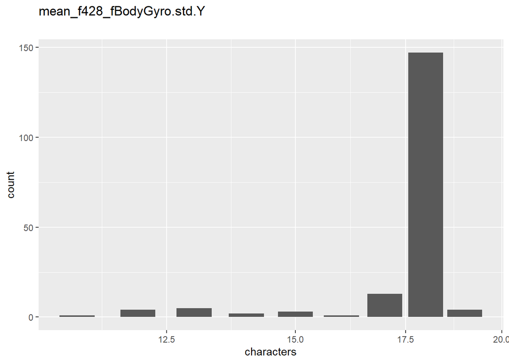

Distribution of values for mean_f428_fBodyGyro.std.Y

0 missing values.

#### Summary statistics

| name | data_type | n_missing | complete_rate | n_unique | empty | min | max | whitespace | label |
| --- | --- | --- | --- | --- | --- | --- | --- | --- | --- |
| mean_f428_fBodyGyro.std.Y | character | 0 | 1 | 180 | 0 | 11 | 19 | 0 | NA |

### mean_f429_fBodyGyro.std.Z

#### Distribution

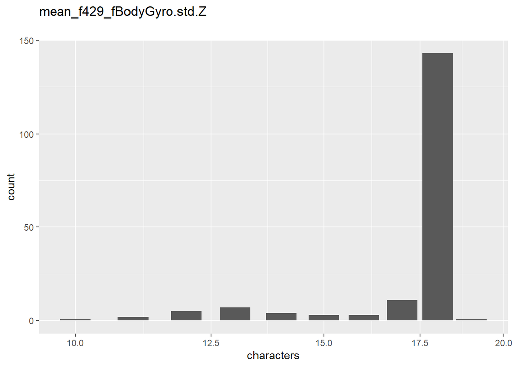

Distribution of values for mean_f429_fBodyGyro.std.Z

0 missing values.

#### Summary statistics

| name | data_type | n_missing | complete_rate | n_unique | empty | min | max | whitespace | label |
| --- | --- | --- | --- | --- | --- | --- | --- | --- | --- |
| mean_f429_fBodyGyro.std.Z | character | 0 | 1 | 180 | 0 | 10 | 19 | 0 | NA |

### mean_f503_fBodyAccMag.mean

#### Distribution

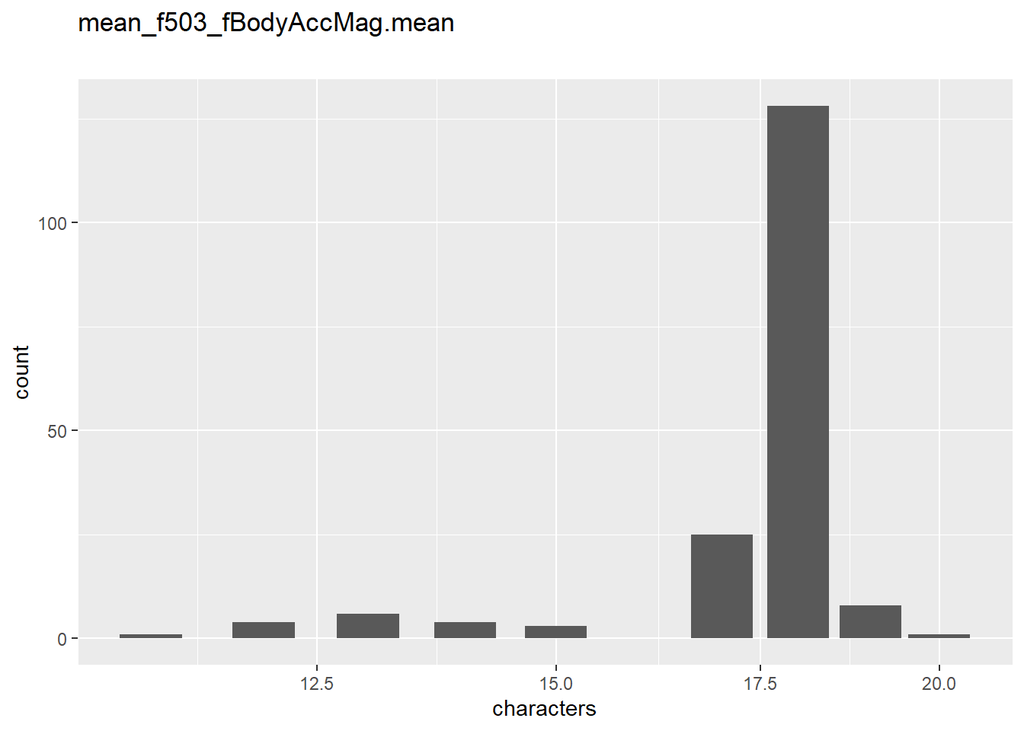

Distribution of values for mean_f503_fBodyAccMag.mean

0 missing values.

#### Summary statistics

| name | data_type | n_missing | complete_rate | n_unique | empty | min | max | whitespace | label |
| --- | --- | --- | --- | --- | --- | --- | --- | --- | --- |
| mean_f503_fBodyAccMag.mean | character | 0 | 1 | 180 | 0 | 11 | 20 | 0 | NA |

### mean_f504_fBodyAccMag.std

#### Distribution

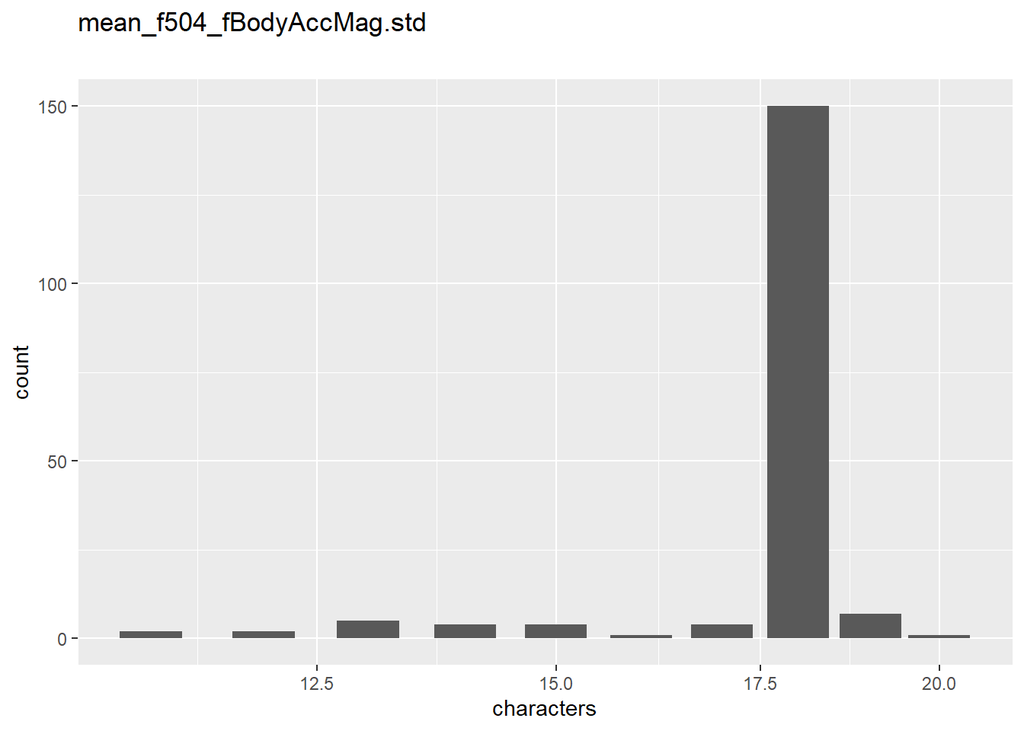

Distribution of values for mean_f504_fBodyAccMag.std

0 missing values.

#### Summary statistics

| name | data_type | n_missing | complete_rate | n_unique | empty | min | max | whitespace | label |
| --- | --- | --- | --- | --- | --- | --- | --- | --- | --- |
| mean_f504_fBodyAccMag.std | character | 0 | 1 | 180 | 0 | 11 | 20 | 0 | NA |

### mean_f516_fBodyBodyAccJerkMag.mean

#### Distribution

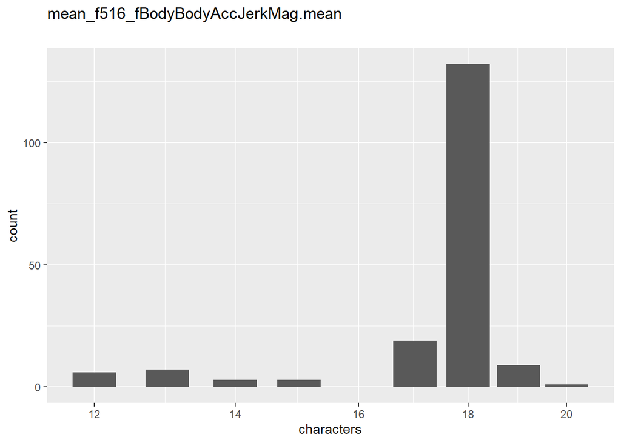

Distribution of values for mean_f516_fBodyBodyAccJerkMag.mean

0 missing values.

#### Summary statistics

| name | data_type | n_missing | complete_rate | n_unique | empty | min | max | whitespace | label |
| --- | --- | --- | --- | --- | --- | --- | --- | --- | --- |
| mean_f516_fBodyBodyAccJerkMag.mean | character | 0 | 1 | 180 | 0 | 12 | 20 | 0 | NA |

### mean_f517_fBodyBodyAccJerkMag.std

#### Distribution

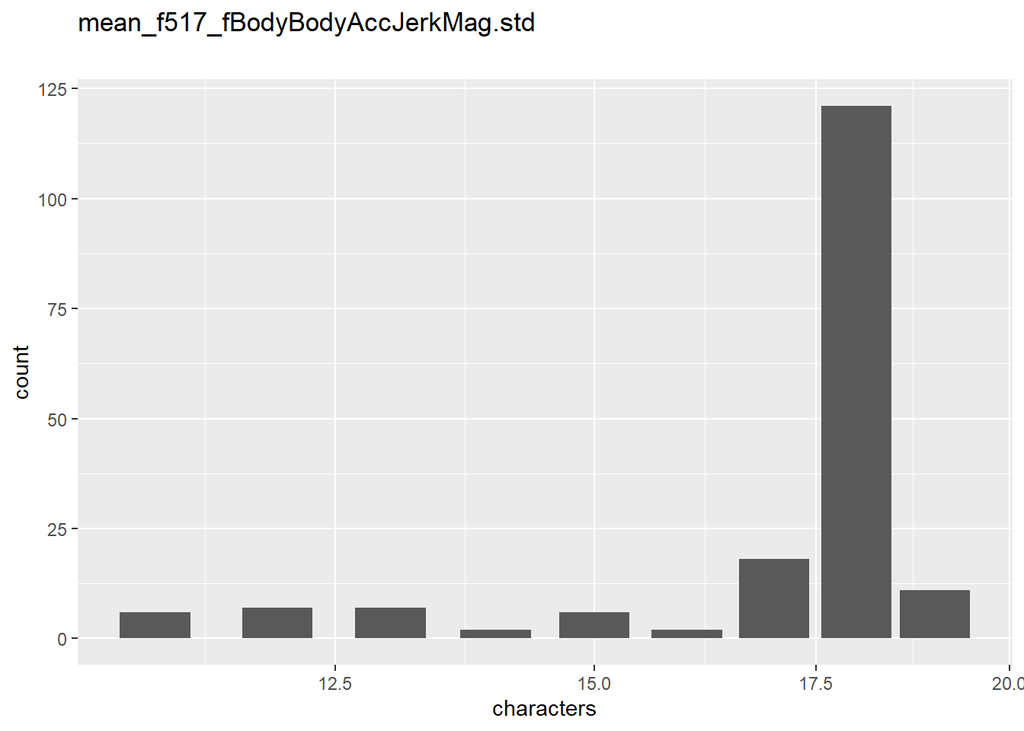

Distribution of values for mean_f517_fBodyBodyAccJerkMag.std

0 missing values.

#### Summary statistics

| name | data_type | n_missing | complete_rate | n_unique | empty | min | max | whitespace | label |
| --- | --- | --- | --- | --- | --- | --- | --- | --- | --- |
| mean_f517_fBodyBodyAccJerkMag.std | character | 0 | 1 | 180 | 0 | 11 | 19 | 0 | NA |